# ETH Zürich - Social Network Analysis project

Andriy Osemchuk

May 8, 2023

# Network Hypothesis

## 1. Dataset overview

### Choosing dataset

We picked a dataset *covert_2* “9/11 Hijackers”.

source: https://sites.google.com/site/ucinetsoftware/datasets/covert-networks/911-hijackers?authuser=0

The network includes data about total 60 terrorists involved in the 9/11, 2001 tragic events. The network is divided on two sub-networks trusted prior contacts (19 hijackers) network and associates network (60 terrorists including hijackers). The data was gathered by the literature and journalistic review, and the ties are described by both personal relationships between terrorists and their affiliation to the flights.

#### Dataset attributes description

Following the link to the source data above, we get the following attributes data description

DATA: 1-mode matrix 19 x 19 person by person of trusted prior contacts and 1-mode matrix 61 x 61 of other associates.

Ties are undirected and binary. Relations are a mix of prior-contacts like trained together, lived together, financial transactions, at school with, on same flight.

- **Network Strength**
  - 1 = Trusted Prior Contacts
  - 2 = Other Associates
- **Ties**
  - 1 = AA #11 WTC North
  - 2 = AA #77 Pentagon
  - 3 = UA #93 Pennsylvania
  - 4 = UA #175 WTC South
  - 5 = Other Associates
- **Las Vegas Meeting**
  - 1 = Attended
  - 0 = Did Not Attend

#### Data loading

```r
Hijackers911.igraph <- covert_2 # 9/11 Hijackers
Hijackers911.igraph
```

```
## [[1]]
## IGRAPH 4cd5fd5 UN-- 60 126 -- 9_11_HIJACKERS_ASSOCIATES
## + attr: name (g/c), name (v/c)
## + edges from 4cd5fd5 (vertex names):
##  [1] Majed Moqed      --Hani Hanjour
##  [2] Khalid Al Mihdhar--Hani Hanjour
##  [3] Khalid Al Mihdhar--Nawaf Alhazmi
##  [4] Khalid Al Mihdhar--Osama Awadallah
##  [5] Khalid Al Mihdhar--Abdussattar Shaikh
##  [6] Hani Hanjour     --Nawaf Alhazmi
##  [7] Hani Hanjour     --Lofti Raissi
##  [8] Hani Hanjour     --Rayed Mohammed Abdullah
## + ... omitted several edges
##
## [[2]]
## IGRAPH 9d43c8b UN-- 19 27 -- 9_11_HIJACKERS_PRIORCONTACTS
## + attr: name (g/c), name (v/c)
## + edges from 9d43c8b (vertex names):
##  [1] Satam Suqami       --Wail Alshehri
##  [2] Satam Suqami       --Waleed Alshehri
##  [3] Wail Alshehri      --Waleed Alshehri
##  [4] Majed Moqed        --Hani Hanjour
##  [5] Waleed Alshehri    --Abdul Aziz Al Omari
##  [6] Salem Alhazmi      --Nawaf Alhazmi
##  [7] Khalid Al Mihdhar  --Hani Hanjour
##  [8] Khalid Al Mihdhar  --Nawaf Alhazmi
## + ... omitted several edges
```

Loading original data used to build igraph object. Loading and preview of 9/11 hijackers associates dataset.

```
## ──────────────────────────────────────────────────────── Delimiter: "," chr
## (1): ...1 dbl (61): Majed Moqed, Khalid Al-Mihdhar, Hani Hanjour, Nawaf
## Alhazmi, Salem...
```

```
## # A tibble: 1 × 62
##   ...1   Majed…¹ Khali…² Hani …³ Nawaf…⁴ Salem…⁵ Ahmed…⁶ Ahmed…⁷ Saeed…⁸ Hamza…⁹
##   <chr>    <dbl>   <dbl>   <dbl>   <dbl>   <dbl>   <dbl>   <dbl>   <dbl>   <dbl>
## 1 Majed…       0       0       1       0       0       0       0       0       0
## # … with 52 more variables: `Ahmed Al Haznawi` <dbl>, `Mohand Alshehri*` <dbl>,
## #   `Fayez Ahmed` <dbl>, `Ziad Jarrah` <dbl>, `Marwan Al-Shehhi` <dbl>,
## #   `Mohamed Atta` <dbl>, `Abdul Aziz Al-Omari*` <dbl>,
## #   `Waleed Alshehri` <dbl>, `Wail Alshehri` <dbl>, `Satam Suqami` <dbl>,
## #   `Raed Hijazi` <dbl>, `Nabil al-Marabh` <dbl>,
## #   `Mustafa Ahamend al-Hisawi` <dbl>, `Mamoun Darkazanli` <dbl>,
## #   `Zakariya Essabar` <dbl>, `Said Bahaji` <dbl>, …
```

Loading and preview of 9/11 hijackers priorcontacts dataset.

```
## ──────────────────────────────────────────────────────── Delimiter: "," chr
## (1): ...1 dbl (19): Satam Suqami, Wail Alshehri, Majed Moqed, Waleed Alshehri,
## Salem A...
```

```
## # A tibble: 1 × 20
##   ...1   Satam…¹ Wail …² Majed…³ Walee…⁴ Salem…⁵ Khali…⁶ Hani …⁷ Abdul…⁸ Ahmed…⁹
##   <chr>    <dbl>   <dbl>   <dbl>   <dbl>   <dbl>   <dbl>   <dbl>   <dbl>   <dbl>
## 1 Satam…       0       1       0       1       0       0       0       0       0
## # … with 10 more variables: `Ahmed Alnami` <dbl>, `Mohamed Atta` <dbl>,
## #   `Marwan Al-Shehhi` <dbl>, `Fayez Ahmed` <dbl>, `Nawaf Alhazmi` <dbl>,
## #   `Ziad Jarrah` <dbl>, `Mohand Alshehri*` <dbl>, `Saeed Alghamdi*` <dbl>,
## #   `Ahmed Al Haznawi` <dbl>, `Hamza Alghamdi` <dbl>, and abbreviated variable
## #   names ¹`Satam Suqami`, ²`Wail Alshehri`, ³`Majed Moqed`,
## #   ⁴`Waleed Alshehri`, ⁵`Salem Alhazmi*`, ⁶`Khalid Al-Mihdhar`,
## #   ⁷`Hani Hanjour`, ⁸`Abdul Aziz Al-Omari*`, ⁹`Ahmed Alghamdi`
```

Loading and preview of 9/11 hijackers priorcontacts and associates attributes dataset.

```
## ──────────────────────────────────────────────────────── Delimiter: "," chr
## (1): ...1 dbl (3): Network Strength, Ties, Las Vegas Meeting
```

```
## # A tibble: 1 × 4
##   ...1        `Network Strength`  Ties `Las Vegas Meeting`
##   <chr>                    <dbl> <dbl>               <dbl>
## 1 Majed Moqed                  1     2                   0
```

#### Data wrangling and data transformations

Transforming hijackers prior contacts data.

```r
# make the first column in the dataframe as a rowname
df_911_HIJACKERS_PRIORCONTACTS <- as.data.frame(df_911_HIJACKERS_PRIORCONTACTS)
colnames(df_911_HIJACKERS_PRIORCONTACTS)[1] <- "names"

head(df_911_HIJACKERS_PRIORCONTACTS, 1)
```

```
##          names Satam Suqami Wail Alshehri Majed Moqed Waleed Alshehri
## 1 Satam Suqami            0             1           0               1
##   Salem Alhazmi* Khalid Al-Mihdhar Hani Hanjour Abdul Aziz Al-Omari*
## 1              0                 0            0                    0
##   Ahmed Alghamdi Ahmed Alnami Mohamed Atta Marwan Al-Shehhi Fayez Ahmed
## 1              0            0            0                0           0
##   Nawaf Alhazmi Ziad Jarrah Mohand Alshehri* Saeed Alghamdi* Ahmed Al Haznawi
## 1             0           0                0               0                0
##   Hamza Alghamdi
## 1              0
```

Transforming hijackers associates contacts data.

Duplicated records were spotted in the original dataset.

```r
length(unique(df_911_HIJACKERS_ASSOCIATES[ , 1]))
```

```
## [1] 1
```

```r
length((df_911_HIJACKERS_ASSOCIATES[ , 1]))
```

```
## [1] 1
```

Search for the duplicated contact record.

```r
n_occur <- data.frame(table(df_911_HIJACKERS_ASSOCIATES$...1))
n_occur[n_occur$Freq > 1,]
```

```
##              Var1 Freq
## 55 Tarek Maaroufi    2
```

Show rows with duplicated contact data. Since we have only one duplicate we can compare the data visually.

```r
subset(df_911_HIJACKERS_ASSOCIATES, ...1 == "Tarek Maaroufi")[ , ]
```

```
## # A tibble: 2 × 62
##   ...1   Majed…¹ Khali…² Hani …³ Nawaf…⁴ Salem…⁵ Ahmed…⁶ Ahmed…⁷ Saeed…⁸ Hamza…⁹
##   <chr>    <dbl>   <dbl>   <dbl>   <dbl>   <dbl>   <dbl>   <dbl>   <dbl>   <dbl>
## 1 Tarek…       0       0       0       0       0       0       0       0       0
## 2 Tarek…       0       0       0       0       0       0       0       0       0
## # … with 52 more variables: `Ahmed Al Haznawi` <dbl>, `Mohand Alshehri*` <dbl>,
## #   `Fayez Ahmed` <dbl>, `Ziad Jarrah` <dbl>, `Marwan Al-Shehhi` <dbl>,
## #   `Mohamed Atta` <dbl>, `Abdul Aziz Al-Omari*` <dbl>,
## #   `Waleed Alshehri` <dbl>, `Wail Alshehri` <dbl>, `Satam Suqami` <dbl>,
## #   `Raed Hijazi` <dbl>, `Nabil al-Marabh` <dbl>,
## #   `Mustafa Ahamend al-Hisawi` <dbl>, `Mamoun Darkazanli` <dbl>,
## #   `Zakariya Essabar` <dbl>, `Said Bahaji` <dbl>, …
```

Observing the records of the contact apparently they are identical. Hence, one record can be dropped. E.g. the record with a higher index value.

```r
df_911_HIJACKERS_ASSOCIATES <- df_911_HIJACKERS_ASSOCIATES[-c(57), -c(57)] #drop matrix row and column

subset(df_911_HIJACKERS_ASSOCIATES, ...1 == "Tarek Maaroufi")[ , ] #verify duplicate is dropped
```

```
## # A tibble: 1 × 61
##   ...1   Majed…¹ Khali…² Hani …³ Nawaf…⁴ Salem…⁵ Ahmed…⁶ Ahmed…⁷ Saeed…⁸ Hamza…⁹
##   <chr>    <dbl>   <dbl>   <dbl>   <dbl>   <dbl>   <dbl>   <dbl>   <dbl>   <dbl>
## 1 Tarek…       0       0       0       0       0       0       0       0       0
## # … with 51 more variables: `Ahmed Al Haznawi` <dbl>, `Mohand Alshehri*` <dbl>,
## #   `Fayez Ahmed` <dbl>, `Ziad Jarrah` <dbl>, `Marwan Al-Shehhi` <dbl>,
## #   `Mohamed Atta` <dbl>, `Abdul Aziz Al-Omari*` <dbl>,
## #   `Waleed Alshehri` <dbl>, `Wail Alshehri` <dbl>, `Satam Suqami` <dbl>,
## #   `Raed Hijazi` <dbl>, `Nabil al-Marabh` <dbl>,
## #   `Mustafa Ahamend al-Hisawi` <dbl>, `Mamoun Darkazanli` <dbl>,
## #   `Zakariya Essabar` <dbl>, `Said Bahaji` <dbl>, …
```

Transforming hijackers associates contacts data.

```r
# make the first column in the dataframe as rowname
df_911_HIJACKERS_ASSOCIATES <- as.data.frame(df_911_HIJACKERS_ASSOCIATES)
colnames(df_911_HIJACKERS_ASSOCIATES)[1] <- "names"

head(df_911_HIJACKERS_ASSOCIATES, 1)
```

```
##         names Majed Moqed Khalid Al-Mihdhar Hani Hanjour Nawaf Alhazmi
## 1 Majed Moqed           0                 0            1             0
##   Salem Alhazmi* Ahmed Alnami Ahmed Alghamdi Saeed Alghamdi* Hamza Alghamdi
## 1              0            0              0               0              0
##   Ahmed Al Haznawi Mohand Alshehri* Fayez Ahmed Ziad Jarrah Marwan Al-Shehhi
## 1                0                0           0           0                0
##   Mohamed Atta Abdul Aziz Al-Omari* Waleed Alshehri Wail Alshehri Satam Suqami
## 1            0                    0               0             0            0
##   Raed Hijazi Nabil al-Marabh Mustafa Ahamend al-Hisawi Mamoun Darkazanli
## 1           0               0                         0                 0
##   Zakariya Essabar Said Bahaji Mounir El Motassadeq Zacarias Moussaoui
## 1                0           0                    0                  0
##   Ramzi Bin al-Shibh Agus Budiman Ahed Khalil Ibrahim Samir Al-Ani Lofti Raissi
## 1                  0            0                                0            0
##   Rayed Mohammed Abdullah Bandar Alhazmi Faisal Al Salmi Osama Awadallah
## 1                       0              0               0               0
##   Abdussattar Shaikh Mohamed Abdi Mohamed Belfas Imad Eddin Baraat Yarkas
## 1                  0            0              0                        0
##   Tarek Maaroufi...41 Abu Qatada Djamal Benghal Jerome Courtaillier
## 1                   0          0              0                   0
##   David Courtaillier Ahmen Ressam Abu Walid Jean-Marc Grandvisir Abu Zubeida
## 1                  0            0         0                    0           0
##   Nizar Trabelsi Haydar Abu Doha Mehdi Khammoun Mohammed Bensakhria
## 1              0               0              0                   0
##   Lased Ben Heni Essid Sami Ben Khemail Seifallah ben Hassine
## 1              0                      0                     0
##   Tarek Maaroufi...58 Fahid al Shakri Madjid Sahoune Samir Kishk Kamel Daoudi
## 1                   0               0              0           0            0
```

Transforming hijackers attributes data.

Checking for direct duplicates.

```r
n_occur <- data.frame(table(df_911_HIJACKERS_ATTR$...1))
n_occur[n_occur$Freq > 1,]
```

```
## [1] Var1 Freq
## <0 rows> (or 0-length row.names)
```

The query returned no duplicates. However, length of the attributes dataframe is off by exactly one record. The assunption is there is a typo in the first of last name of the hijacker.

Let’s search by last name first.

```r
duplicate_search_results <- base::grepl(pattern= "Maaroufi", x = df_911_HIJACKERS_ATTR$...1)

duplicate_search_results_index <-  which(duplicate_search_results == TRUE)
duplicate_search_results_index
```

```
## [1] 40 57
```

Apparently, the last name is the same. We can check these records by the indices to see what is going on. It looks like there might a typo in the First name *Tarek* vs *Takek*.

```r
df_911_HIJACKERS_ATTR[duplicate_search_results_index, ]
```

```
## # A tibble: 2 × 4
##   ...1           `Network Strength`  Ties `Las Vegas Meeting`
##   <chr>                       <dbl> <dbl>               <dbl>
## 1 Tarek Maaroufi                  2     5                   0
## 2 Takek Maaroufi                  2     5                   0
```

After doing some google/bing search and using help of ChatGPT it looks like Tarek Maaroufi is our guy. Google, Bing and ChatGPT knows nothing about the other person.

Hence, the record with the name Takek Maaroufi can be dropped.

```r
df_911_HIJACKERS_ATTR <- df_911_HIJACKERS_ATTR[-c(57), ]
# verify duplicate is dropped and instead the index is assigned to the next person
df_911_HIJACKERS_ATTR[duplicate_search_results_index, ]
```

```
## # A tibble: 2 × 4
##   ...1            `Network Strength`  Ties `Las Vegas Meeting`
##   <chr>                        <dbl> <dbl>               <dbl>
## 1 Tarek Maaroufi                   2     5                   0
## 2 Fahid al Shakri                  2     5                   0
```

```r
# make the first column in the dataframe as rowname
df_911_HIJACKERS_ATTR <- as.data.frame(df_911_HIJACKERS_ATTR)
colnames(df_911_HIJACKERS_ATTR)[1] <- "names"

head(df_911_HIJACKERS_ATTR, 3)
```

```
##               names Network Strength Ties Las Vegas Meeting
## 1       Majed Moqed                1    2                 0
## 2 Khalid Al-Mihdhar                1    2                 0
## 3      Hani Hanjour                1    2                 1
```

### Calculate some network descriptive metrics

#### Network size

The networks size is calculated below.

```r
dim(df_911_HIJACKERS_PRIORCONTACTS)[1]
```

```
## [1] 19
```

```r
dim(df_911_HIJACKERS_ASSOCIATES)[1]
```

```
## [1] 60
```

#### Network densities

The networks density is calculated below.

```r
gden(df_911_HIJACKERS_PRIORCONTACTS[2:20])
```

```
## [1] 0.1403509
```

```r
gden(df_911_HIJACKERS_ASSOCIATES[2:61])
```

```
## [1] 0.05368748
```

Network density is a measure of how many connections there are in a network compared to the total number of possible connections. It is calculated by dividing the number of edges by the number of possible edges. Density is used to understand how connected the network is compared to how connected it might be. It can also tell us how two networks with the same number of nodes and the same type of relationships are different.

When the density result is compared with networks we have already studied like school friendships. The network density results are low. Especially, in the associate’s network. It means nodes are less connected to each other. The explanation for this fact could be hijackers trusted each other more than the network of associates. At the same time, the other implications are the desire to keep secrecy and making sure if one node is exposed there is a minimum risk of exposing others. On the contrary, in a school friendship network, there is more trust between nodes.

#### Average degree

Average in degree and out degree for HIJACKERS PRIORCONTACTS

```r
averageInDegree_priorContacts <- mean( colSums(df_911_HIJACKERS_PRIORCONTACTS[2:20]) )
cat("Average indegree hijackers prior contacts is: ", averageInDegree_priorContacts)
```

```
## Average indegree hijackers prior contacts is:  2.526316
```

```r
averageOutDegree_priorContacts <- mean( rowSums(df_911_HIJACKERS_PRIORCONTACTS[2:20]) )
cat("Average outdegree hijackers prior contacts is: ", averageOutDegree_priorContacts)
```

```
## Average outdegree hijackers prior contacts is:  2.526316
```

Average in degree and out degree for HIJACKERS ASSOCIATES

```r
averageOutDegree_associates <- mean( rowSums(df_911_HIJACKERS_ASSOCIATES[2:61]), na.rm = TRUE )
cat("Average outdegree hijackers hijackers associates is: ", averageOutDegree_associates)
```

```
## Average outdegree hijackers hijackers associates is:  3.101695
```

```r
averageInDegree_associates <- mean( colSums(df_911_HIJACKERS_ASSOCIATES[2:61]), na.rm = TRUE )
cat("Average indegree hijackers associates is: ", averageInDegree_associates)
```

```
## Average indegree hijackers associates is:  3.20339
```

As an alternative, we might consider also calculation of the average degree of individuals as a double-check:

```r
averageInDegree_priorContacts_individuals <-  sum(df_911_HIJACKERS_PRIORCONTACTS[2:20])/dim(df_911_HIJACKERS_PRIORCONTACTS[2:20])[1]
cat("The Average degree of hijackers prior contacts individuals is: ", averageInDegree_priorContacts_individuals)
```

```
## The Average degree of hijackers prior contacts individuals is:  2.526316
```

```r
averageInDegree_associates_individuals <- sum(df_911_HIJACKERS_ASSOCIATES[2:61], na.rm = T)/dim(df_911_HIJACKERS_ASSOCIATES)[1]
cat("The Average degree of hijackers associates individuals is: ", averageInDegree_associates_individuals)
```

```
## The Average degree of hijackers associates individuals is:  3.183333
```

The average degree in both terrorist networks is also low in comparison to the school friendship network (4.88). It contributes to the idea of keeping secrecy and keeping at minimum exposure risks suggesting that each person is connected to about 2-3 others on average.

#### Correlation and distribution

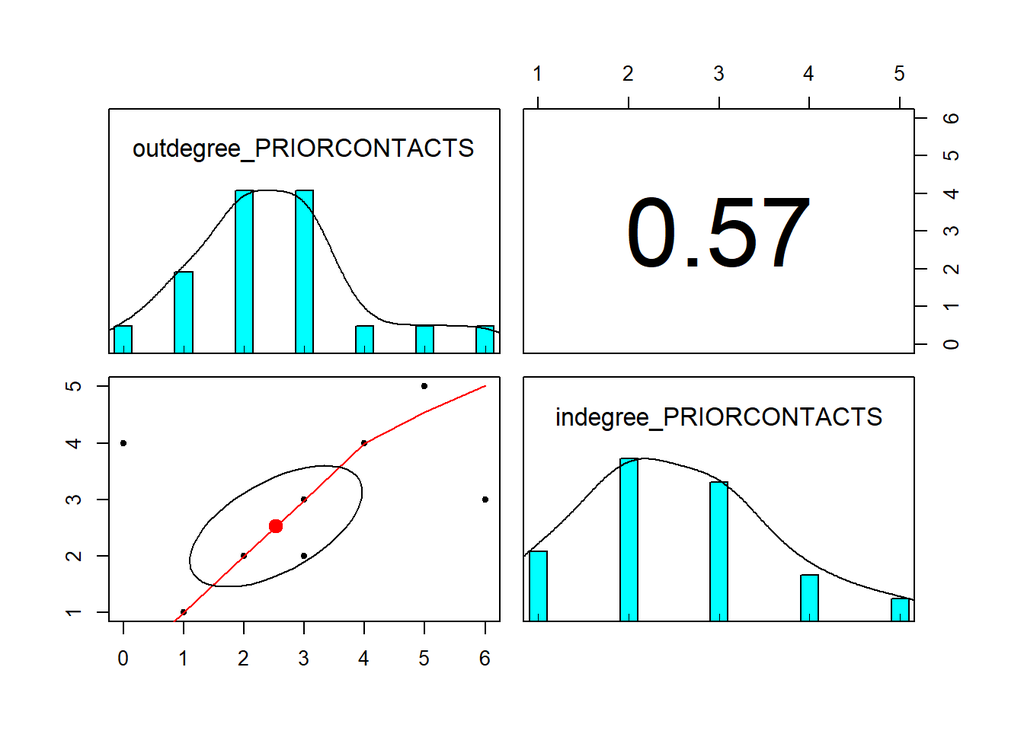

```r
# the sum of rows is the outdegree, see Lecture 1
outdegree_PRIORCONTACTS <- rowSums(df_911_HIJACKERS_PRIORCONTACTS[,2:20])
# the sum of columns is the indegree, see Lecture 1
indegree_PRIORCONTACTS <- colSums(df_911_HIJACKERS_PRIORCONTACTS[2:20])

psych::pairs.panels(data.frame(outdegree_PRIORCONTACTS, indegree_PRIORCONTACTS))
```

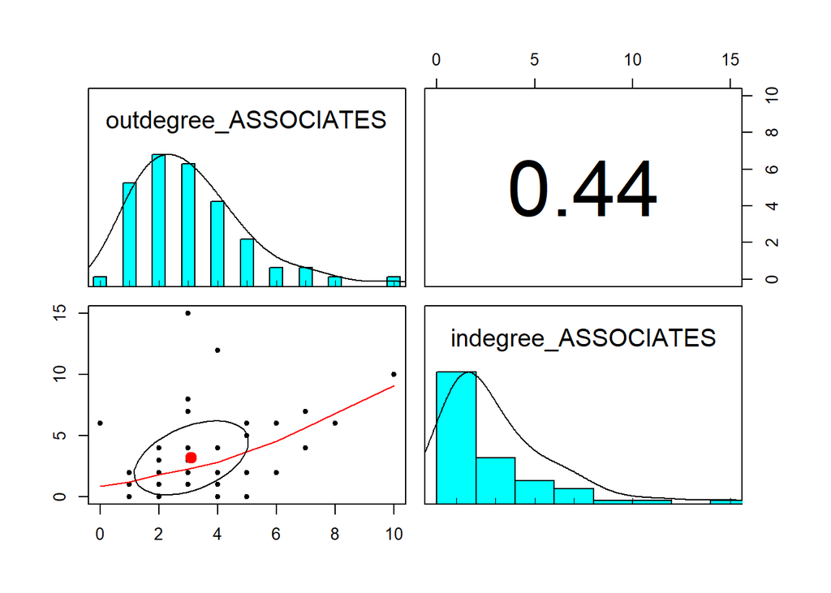

```r
outdegree_ASSOCIATES <- rowSums(df_911_HIJACKERS_ASSOCIATES[2:61]) # the sum of rows is the outdegree, see Lecture 1
indegree_ASSOCIATES <- colSums(df_911_HIJACKERS_ASSOCIATES[2:61])# the sum of columns is the indegree, see Lecture 1

psych::pairs.panels(data.frame(outdegree_ASSOCIATES, indegree_ASSOCIATES))
```

The correlation coefficient between in-degree and out-degree can be used to measure how well-connected a node is within a network. The correlation coefficients in both terrorist networks in comparison with the school network are much higher 57% and 44% against 14% in the school. Implying a moderate to strong positive correlation between the number of incoming and outgoing ties.

#### Reciprocity ratio

The reciprocity ratio is calculated below.

```r
cat("PRIORCONTACTS reciprocity ratio of dyadic ties which are symmetric: ", grecip(df_911_HIJACKERS_PRIORCONTACTS[2:20], measure = "dyadic"))
```

```
## PRIORCONTACTS reciprocity ratio of dyadic ties which are symmetric:  0.9649123
```

```r
cat("PRIORCONTACTS reciprocity ratio of mutuals to non-null dyads: ", grecip(df_911_HIJACKERS_PRIORCONTACTS[2:20], measure = "dyadic.nonnull"))
```

```
## PRIORCONTACTS reciprocity ratio of mutuals to non-null dyads:  0.7777778
```

```r
cat("ASSOCIATES reciprocity ratio of dyadic ties which are symmetric: ", grecip(df_911_HIJACKERS_ASSOCIATES[2:61], measure = "dyadic"))
```

```
## ASSOCIATES reciprocity ratio of dyadic ties which are symmetric:  0.9660825
```

```r
cat("ASSOCIATES reciprocity ratio of mutuals to non-null dyads: ", grecip(df_911_HIJACKERS_ASSOCIATES[2:61], measure = "dyadic.nonnull"))
```

```
## ASSOCIATES reciprocity ratio of mutuals to non-null dyads:  0.52
```

The reciprocity ratio, a measure of mutual symmetric connections (“dyadic”), is ~ 96% in comparison with 82.3% in school network, signifying that the ties are reciprocal. Dyadic.nonnull returns the ratio of mutuals to non-null dyads which is also high 77.7% & 52% when in the school network it is 37%. Hence, the implication could be there is possibly more trust within the terrorist like networks.

#### Centrality

Centrality is a key feature in social network analysis - as the name suggests, it is about describing what are central nodes in the network. Degree of centrality is the sum of incoming/outgoing/total ties each individual has.

```r
# get only prior contacts from df_911_HIJACKERS_ATTR by joining hijackers prior contacts df
df_911_HIJACKERS_ATTR_PRIORCONTACTS <- right_join(df_911_HIJACKERS_ATTR, df_911_HIJACKERS_PRIORCONTACTS, by= c("names" = "names") )

# calculate centrality and assign to the new column
df_911_HIJACKERS_ATTR_PRIORCONTACTS$centralityPrior <-
  sna::degree(df_911_HIJACKERS_ATTR_PRIORCONTACTS[5:23], cmode = 'freeman')

# rearrange columns order and select specific columns
df_911_HIJACKERS_ATTR_PRIORCONTACTS <-
  df_911_HIJACKERS_ATTR_PRIORCONTACTS %>% select(c("names", "Network Strength", "Ties", "Las Vegas Meeting", "centralityPrior"))

# sort df in descending order
df_911_HIJACKERS_ATTR_PRIORCONTACTS %>%
  arrange(desc(centralityPrior)) %>% head(3)
```

```
##              names Network Strength Ties Las Vegas Meeting centralityPrior
## 1    Nawaf Alhazmi                1    2                 1               9
## 2 Marwan Al-Shehhi                1    4                 1               7
## 3  Waleed Alshehri                1    1                 0               7
```

```r
# get only associates from df_911_HIJACKERS_ATTR by joining hijackers prior contacts df
df_911_HIJACKERS_ATTR_ASSOCIATES <- right_join(df_911_HIJACKERS_ATTR, df_911_HIJACKERS_ASSOCIATES, by= c("names" = "names") )

# calculate centrality and assign to the new column
df_911_HIJACKERS_ATTR_ASSOCIATES$centralityAssociates <-
  sna::degree(df_911_HIJACKERS_ATTR_ASSOCIATES[5:64], cmode = 'freeman')

# rearrange columns order and select specific columns
df_911_HIJACKERS_ATTR_ASSOCIATES <-
  df_911_HIJACKERS_ATTR_ASSOCIATES %>% select(c("names", "Network Strength", "Ties", "Las Vegas Meeting", "centralityAssociates"))

# sort df in descending order
df_911_HIJACKERS_ATTR_ASSOCIATES %>%
  arrange(desc(centralityAssociates)) %>% head(3)
```

```
##                    names Network Strength Ties Las Vegas Meeting
## 1 Essid Sami Ben Khemail                2    5                 0
## 2           Mohamed Atta                1    1                 1
## 3       Marwan Al-Shehhi                1    4                 1
##   centralityAssociates
## 1                   20
## 2                   18
## 3                   16
```

The model shows the Essid Sami Ben Khemail being the central node in the network. Not suprisingly, when you google it, then it turns out he is a head of al-Qaeda. One more discovery is that Osama bin Laden is absent in the dataset at all.

```r
# join back the calculated centrality column to the df_911_HIJACKERS_ATTR
df_911_HIJACKERS_ATTR <- left_join(df_911_HIJACKERS_ATTR, df_911_HIJACKERS_ATTR_ASSOCIATES[ ,c("names", "centralityAssociates")], by= c("names" = "names") )
df_911_HIJACKERS_ATTR <- left_join(df_911_HIJACKERS_ATTR, df_911_HIJACKERS_ATTR_PRIORCONTACTS[ ,c("names", "centralityPrior")], by= c("names" = "names") )

head(df_911_HIJACKERS_ATTR)
```

```
##               names Network Strength Ties Las Vegas Meeting
## 1       Majed Moqed                1    2                 0
## 2 Khalid Al-Mihdhar                1    2                 0
## 3      Hani Hanjour                1    2                 1
## 4     Nawaf Alhazmi                1    2                 1
## 5    Salem Alhazmi*                1    2                 1
## 6      Ahmed Alnami                1    3                 0
##   centralityAssociates centralityPrior
## 1                    2               3
## 2                    6               4
## 3                   10               2
## 4                   12               9
## 5                    2               2
## 6                    4               4
```

### Visualizing 9_11_HIJACKERS_PRIORCONTACTS

#### Create the layout of 9_11_HIJACKERS_PRIORCONTACTS

```r
matrix_911_HIJACKERS_PRIORCONTACTS <-  as.matrix(df_911_HIJACKERS_PRIORCONTACTS[2:20])
priorContacts.911.igraph <- graph_from_adjacency_matrix(matrix_911_HIJACKERS_PRIORCONTACTS,
                          mode = "undirected", weighted = TRUE, diag = FALSE)
```

```r
# join prior contacts matrix info with hijackers prior contacts attributes
PRIORCONTACTS <- inner_join(df_911_HIJACKERS_PRIORCONTACTS, df_911_HIJACKERS_ATTR_PRIORCONTACTS, by= c("names" = "names") )
```

#### Vizualization HIJACKERS_PRIORCONTACTS central contact

This is a visualization of the sub-network with Central node being colored as blue, size is the centrality degree, plotting based on Kamada-Kawai layout algorithm and direction (arrows).

```r
set.seed(7)
layout.graph.priorContacts2 <- create_layout(priorContacts.911.igraph,
                          layout = 'kk')    # doing the layout with kk
```

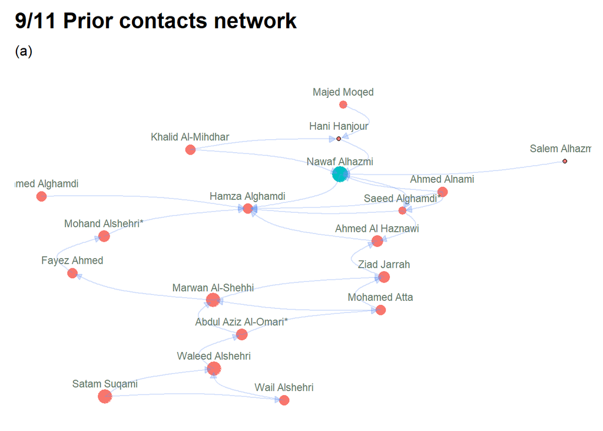

```r
# algorithm to determine the terrorist name with max centrality
name_max <-  as.character(
  df_911_HIJACKERS_ATTR_PRIORCONTACTS %>%
  filter(centralityPrior == max(centralityPrior)) %>%
  select(c("names"))
  )

# plotting
ggraph(layout.graph.priorContacts2) +
  geom_node_point() +
  geom_node_point(
    aes(
      colour = PRIORCONTACTS$names == name_max,
      size = PRIORCONTACTS$centralityPrior),
    show.legend = FALSE
  ) +
  # geom_edge_link(alpha = .3, colour = "#6795f0") +
  geom_node_text(
    aes(label = name),
    size = 3,
    colour = '#617566',
    nudge_y = 0.2, # adjust on y axis display of the terrorist name
    show.legend = FALSE
  )  +
  geom_edge_arc(aes(),
                strength = 0.25,
                end_cap=circle(radius=1, unit = 'mm'),
                arrow = arrow(length = unit(2, 'mm'), type="closed"),
                alpha = .3, colour = "#6795f0"
                ) +
  ggtitle("9/11 Prior contacts network") +
  labs(subtitle = "(a)") +
  theme_graph(plot_margin = margin(10, 10, 10, 10))
```

According to the centrality index, as we can see on the plot the central node (broker) is **Nawaf Alhamzi**.

#### Vizualization HIJACKERS_PRIORCONTACTS flight details

```r
set.seed(7)
layout.graph.priorContacts4 <- create_layout(priorContacts.911.igraph,
                          layout = 'kk')    # doing the layout with Kamada-Kawai
```

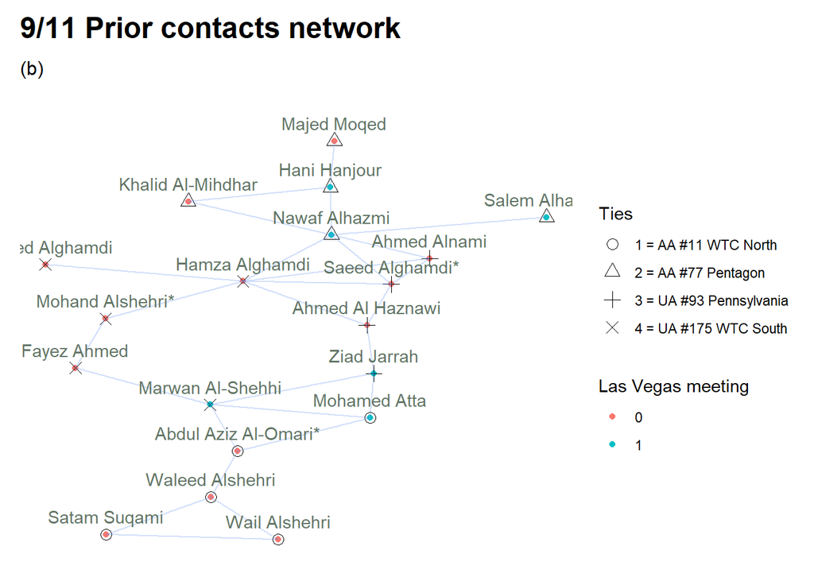

```r
# algorithm to determine the terrorist name with max centrality
name_max <-  as.character(
  df_911_HIJACKERS_ATTR_PRIORCONTACTS %>%
  filter(centralityPrior == max(centralityPrior)) %>%
  select(c("names"))
  )

`Size Centrality` = PRIORCONTACTS$centralityPrior
`Max Centrality` = PRIORCONTACTS$names == name_max
`Las Vegas meeting` = as.factor(PRIORCONTACTS$`Las Vegas Meeting`)

# plotting
ggraph(layout.graph.priorContacts4) +
  geom_node_point(aes(#size = `Size Centrality`,
                      colour= `Las Vegas meeting`)
  ) +
  geom_node_point(
    aes(
      # colour = `Max Centrality`,
      shape= as.factor(PRIORCONTACTS$Ties)
      ),
    size=3
  ) +
  geom_edge_link(alpha = .3, colour = "#6795f0") +
  geom_node_text(
    aes(label = name),
    colour = '#617566',
    nudge_y = 0.2, # adjust on y axis display of the terrorist name
    show.legend = FALSE
  )  +
  scale_shape_manual(name= "Ties",
                     values= c(1, 2, 3, 4, 5),
                     labels= c("1 = AA #11 WTC North",
                               "2 = AA #77 Pentagon",
                               "3 = UA #93 Pennsylvania",
                               "4 = UA #175 WTC South",
                               "5 = Other Associates")
  ) +
  # scale_size_manual(name="Centrality size", values = as.factor(PRIORCONTACTS$centralityPrior)) +
    # scale_size_manual(name="Centrality size", breaks = waiver(), values = as.factor(PRIORCONTACTS$centralityPrior)) +
  # labs(color = PRIORCONTACTS$names, size = PRIORCONTACTS$centralityPrior) +
  ggtitle("9/11 Prior contacts network") +
  labs(subtitle = "(b)") +
  theme_graph(plot_margin = margin(10, 10, 10, 10))
```

The sub-network broker **Nawaf Alhamzi** determined on the previous plot also participated in the Las Vegas event which from our point of view confirms his leadership position in the network.

### Visualizing 9_11_HIJACKERS_ASSOCIATES

#### Create the layout of 9_11_HIJACKERS_ASSOCIATES

```r
# replace NA with 0. All NAs are selfreferences
df_911_HIJACKERS_ASSOCIATES <- df_911_HIJACKERS_ASSOCIATES %>% replace(is.na(.), 0) #
# convert to matrix
matrix_911_HIJACKERS_ASSOCIATES <- as.matrix(df_911_HIJACKERS_ASSOCIATES[2:61])
# create ighraph object
associates.911.igraph <- graph_from_adjacency_matrix(matrix_911_HIJACKERS_ASSOCIATES, mode = "undirected", weighted = TRUE, diag = FALSE)
```

```r
# join prior contacts matrix info with hijackers prior contacts attributes
ASSOCIATES <- inner_join(df_911_HIJACKERS_ASSOCIATES, df_911_HIJACKERS_ATTR_ASSOCIATES, by= c("names" = "names") )
```

#### Vizualization HIJACKERS_ASSOCIATES

This is a visualization of the network with Central node being colored as blue, size is the centrality degree, plotting based on Kamada-Kawai layout algorithm and direction (arrows).

```r
set.seed(7)
layout.graph.associateContacts1 <- create_layout(associates.911.igraph,
                          layout = 'kk')    # doing the layout with kk
```

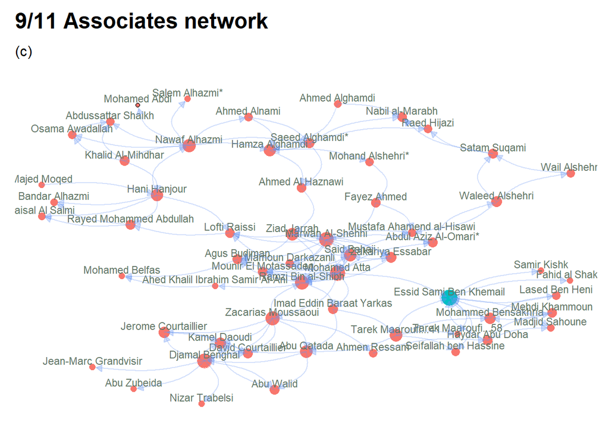

```r
# algorithm to determine the terrorist name with max centrality
name_max <-  as.character(
  df_911_HIJACKERS_ATTR_ASSOCIATES %>%
  filter(centralityAssociates == max(centralityAssociates)) %>%
  select(c("names"))
  )

# plotting
ggraph(layout.graph.associateContacts1) +
  geom_node_point() +
  geom_node_point(
    aes(
      colour = ASSOCIATES$names == name_max,
      size = ASSOCIATES$centralityAssociates),
    show.legend = FALSE
  ) +
  # geom_edge_link(alpha = .3, colour = "#6795f0") +
  geom_node_text(
    aes(label = name),
    size = 3,
    colour = '#617566',
    nudge_y = 0.2, # adjust on y axis display of the terrorist name
    show.legend = FALSE
  )  +
  geom_edge_arc(aes(),
                strength = 0.25,
                end_cap=circle(radius=1, unit = 'mm'),
                arrow = arrow(length = unit(2, 'mm'), type="closed"),
                alpha = .3, colour = "#6795f0"
                ) +
  ggtitle("9/11 Associates network") +
  labs(subtitle = "(c)") +
  theme_graph(plot_margin = margin(10, 10, 10, 10))
```

#### Vizualization HIJACKERS_ASSOCIATES flight details

```r
set.seed(7)
layout.graph.associateContacts2 <- create_layout(associates.911.igraph,
                          layout = 'kk')    # doing the layout with Kamada-Kawai
```

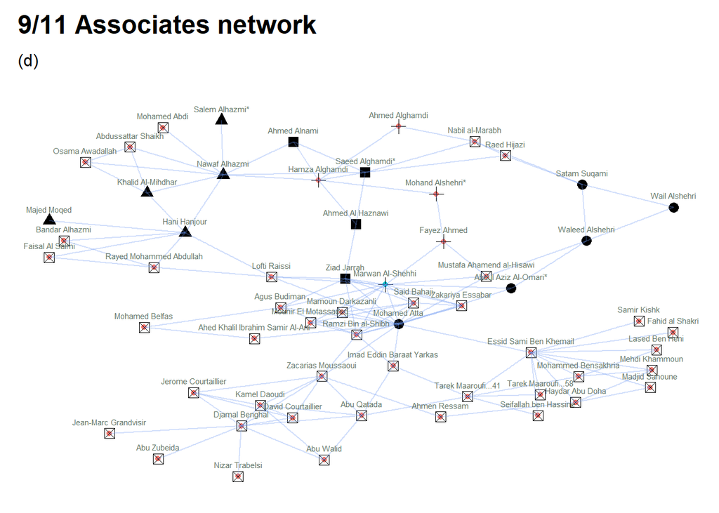

```r
# algorithm to determine the terrorist name with max centrality
name_max <-  as.character(
  df_911_HIJACKERS_ATTR_ASSOCIATES %>%
  filter(centralityAssociates == max(centralityAssociates)) %>%
  select(c("names"))
  )

`Size Centrality` = ASSOCIATES$centralityAssociates
`Max Centrality` = ASSOCIATES$names == name_max
`Las Vegas meeting` = as.factor(ASSOCIATES$`Las Vegas Meeting`)

# plotting
ggraph(layout.graph.associateContacts2) +
  geom_node_point(aes(#size = `Size Centrality`,
                      colour= `Las Vegas meeting`),
                  show.legend=FALSE
  ) +
  geom_node_point(
    aes(
      # colour = `Max Centrality`,
      shape= as.factor(ASSOCIATES$Ties)
      ),
    show.legend=FALSE,
    size=3
  ) +
  geom_edge_link(alpha = .3, colour = "#6795f0") +
  geom_node_text(
    aes(label = name),
    size = 2,
    colour = '#617566',
    nudge_y = 0.3, # adjust on y axis display of the terrorist name
    show.legend = FALSE
  )  +
  ggtitle("9/11 Associates network") +
  labs(subtitle = "(d)") +
  theme_graph(plot_margin = margin(10, 10, 10, 10))
```

**Plot legend**

•

circle = 1 AA #11 WTC North

▲

Triangle = 2 AA #77 Pentagon

■

Square = 3 UA #93 Pennsylvania

+

Plus = 4 UA #175 WTC South

⛝

Square with cross = 5 Other Associates

Terrorist attacks have been a relevant and current topic from the Ukrainian perspective since the full-scale Russian invasion. SNA can help identify the communication patterns of terrorists; Ukrainian law authorities can better understand who is involved, which can be used to disrupt plots and apprehend perpetrators preemptively in wartime in Ukraine.

## 2. Social Network theories

## Answer

### (a)

Theory: Trustworthiness (Trust networks) as a part of Social Capital Theory. Hypothesis: members’ level of trust is higher and more stable within cohesive subgroups/cliques/triads than between leaders and other members or than the level of trust in general. Here additional longitudinal data may be applied using dynamic network analysis.

Having studied terrorist organizations’ structure, Malcolm Sparrow suggests that one of the main network features of criminal networks is a permanent dynamic of fuzzy boundaries and completeness (1991). So, it’s more relevant to learn not the general number of ties (and their strengths) between two or more individuals but to look at the “point” interaction among triads, especially cohesive ones and to study a local trust. We suppose that since the 9/11 network is never static[^1], it’s difficult to observe a high level of permanent trust between leaders and other members.

The theory of trustworthiness is also worth applying based on the following: * Mark Sageman (2004) found that planning and participating in attacks were mainly based on strong social ties within small “cells”: most were friends or relatives in the past, which allows studying a strong sense of community, but precisely with small task activities. * Friedkin (1983) found a huge distance between pairs and triads even in the same flight-attack team. It’s explained by the strategy to minimize damage to the whole network if even one member is compromised.

*This hypothesis could be tested by calculating network measures as per 1(a) across similar terrorist like networks. E.g. “Global Suicide Attacks” (covert_19), “Madrid Train Bombing 2004” (covert_30), etc.*

The other tests we can perform for hypothesis testing are:

- Univariate Conditional Uniform Graph Tests (https://rdrr.io/cran/sna/man/cug.test.html)
- Quadratic Assignment Procedure (QAP) Hypothesis Tests for Graph-Level Statistics (https://rdrr.io/cran/sna/man/qaptest.html)

Both tests take as an input graph matrix object and the function you’d like to use for testing. E.g.:

- *gtrans()* - Compute Transitivity of an Input Graph or Graph Stack (https://rdrr.io/cran/sna/man/gtrans.html)
- *connectedness()* - Compute Graph Connectedness Scores (https://rdrr.io/cran/sna/man/connectedness.html)
- *degree()* - Compute the Degree Centrality Scores of Network Positions (https://rdrr.io/cran/sna/man/degree.html)

### (b)

From the 9/11 Associates network visualization, each leader has a monopoly over local communities rather than over the whole network. Nasrullah Memon describes it as a “free scale network” created spontaneously, without a particular organizational plan, required hierarchy or central authority (2006).

#### Perform a Gould-Fernandez Brokerage Analysis

##### Brokerage Analysis prior contacts

```r
# make terrorist names as rownames of the matrix. So, the output statistics is more informative
rownames(matrix_911_HIJACKERS_PRIORCONTACTS) <- df_911_HIJACKERS_ATTR_PRIORCONTACTS$names

# Perform a Gould-Fernandez Brokerage Analysis
# attribute "Ties" is used as a class (cl) parameter
priorContacts_brokerage <- brokerage(g = matrix_911_HIJACKERS_PRIORCONTACTS, cl=df_911_HIJACKERS_ATTR_PRIORCONTACTS[ , 3])
summary(priorContacts_brokerage)
```

```
## Gould-Fernandez Brokerage Analysis
##
## Global Brokerage Properties
##            t    E(t)   Sd(t)       z Pr(>|z|)
## w_I   6.0000  3.4545  2.5274  1.0072   0.3139
## w_O   4.0000 17.2724  6.4198 -2.0674   0.0387 *
## b_IO 15.0000 17.2724  6.7660 -0.3359   0.7370
## b_OI 15.0000 17.2724  6.7660 -0.3359   0.7370
## b_O  23.0000 43.1809 13.3390 -1.5129   0.1303
## t    63.0000 98.4524 25.8533 -1.3713   0.1703
## ---
## Signif. codes:  0 '***' 0.001 '**' 0.01 '*' 0.05 '.' 0.1 ' ' 1
##
## Individual Properties (by Group)
##
##  Group ID: 2
##                   w_I w_O b_IO b_OI b_O t        w_I        w_O       b_IO
## Majed Moqed         0   0    0    0   0 0 -0.3812605 -0.7519035 -0.5990412
## Khalid Al-Mihdhar   0   0    0    0   0 0 -0.3812605 -0.7519035 -0.5990412
## Hani Hanjour        0   0    0    0   0 0 -0.3812605 -0.7519035 -0.5990412
## Nawaf Alhazmi       0   0    2    2   0 4 -0.3812605 -0.7519035  0.6643772
## Salem Alhazmi*      0   0    0    0   0 0 -0.3812605 -0.7519035 -0.5990412
##                         b_OI        b_O          t
## Majed Moqed       -0.5990412 -0.9018865 -1.0974830
## Khalid Al-Mihdhar -0.5990412 -0.9018865 -1.0974830
## Hani Hanjour      -0.5990412 -0.9018865 -1.0974830
## Nawaf Alhazmi      0.6643772 -0.9018865 -0.2502851
## Salem Alhazmi*    -0.5990412 -0.9018865 -1.0974830
##
##  Group ID: 3
##                  w_I w_O b_IO b_OI b_O t        w_I       w_O       b_IO
## Ahmed Alnami       0   0    0    0   0 0 -0.2921366 -0.795541 -0.5369934
## Saeed Alghamdi*    0   0    0    0   4 4 -0.2921366 -0.795541 -0.5369934
## Ahmed Al Haznawi   0   0    0    0   0 0 -0.2921366 -0.795541 -0.5369934
## Ziad Jarrah        0   0    0    0   2 2 -0.2921366 -0.795541 -0.5369934
##                        b_OI        b_O          t
## Ahmed Alnami     -0.5369934 -0.9440577 -1.0974830
## Saeed Alghamdi*  -0.5369934  0.5426164 -0.2502851
## Ahmed Al Haznawi -0.5369934 -0.9440577 -1.0974830
## Ziad Jarrah      -0.5369934 -0.2007206 -0.6738840
```

[output cut: 13 more lines]

```
## Marwan Al-Shehhi  0.03266797  1.96595455  1.6559102
##
##  Group ID: 1
##                      w_I w_O b_IO b_OI b_O  t        w_I        w_O        b_IO
## Mohamed Atta           0   0    2    2   0  4 -0.3812605 -0.7519035  0.66437716
## Abdul Aziz Al-Omari*   0   0    1    1   0  2 -0.3812605 -0.7519035  0.03266797
## Waleed Alshehri        0   0    0    0   0  0 -0.3812605 -0.7519035 -0.59904123
## Wail Alshehri          3   0    0    0   0  3  5.2474689 -0.7519035 -0.59904123
## Satam Suqami           3   1    4    7   2 17  5.2474689  0.1019970  1.92779556
##                             b_OI         b_O          t
## Mohamed Atta          0.66437716 -0.90188647 -0.2502851
## Abdul Aziz Al-Omari*  0.03266797 -0.90188647 -0.6738840
## Waleed Alshehri      -0.59904123 -0.90188647 -1.0974830
## Wail Alshehri        -0.59904123 -0.90188647 -0.4620845
## Satam Suqami          3.82292315 -0.08250332  2.5031081
```

##### Brokerage Analysis associates

```r
# make terrorist names as rownames of the matrix. So, the output statistics is more informative
rownames(matrix_911_HIJACKERS_ASSOCIATES) <- df_911_HIJACKERS_ATTR_ASSOCIATES$names

# Perform a Gould-Fernandez Brokerage Analysis
# attribute "Ties" is used as a class (cl) parameter
associates_brokerage <- brokerage(g = matrix_911_HIJACKERS_ASSOCIATES, cl=df_911_HIJACKERS_ATTR_ASSOCIATES[ , 3])
summary(associates_brokerage)
```

```
## Gould-Fernandez Brokerage Analysis
##
## Global Brokerage Properties
##            t    E(t)   Sd(t)       z  Pr(>|z|)
## w_I  255.000 176.711  37.600  2.0822  0.037327 *
## w_O    2.000  96.755  22.066 -4.2943 1.753e-05 ***
## b_IO  53.000  96.755  19.061 -2.2955  0.021705 *
## b_OI  68.000  96.755  19.061 -1.5086  0.131411
## b_O   34.000  98.485  24.337 -2.6497  0.008057 **
## t    412.000 565.462  80.587 -1.9043  0.056871 .
## ---
## Signif. codes:  0 '***' 0.001 '**' 0.01 '*' 0.05 '.' 0.1 ' ' 1
##
## Individual Properties (by Group)
##
##  Group ID: 2
##                   w_I w_O b_IO b_OI b_O  t        w_I       w_O       b_IO
## Majed Moqed         0   0    0    0   0  0 -0.1666209 -1.000382 -0.4019721
## Khalid Al-Mihdhar   0   0    0    2   0  2 -0.1666209 -1.000382 -0.4019721
## Hani Hanjour        4   0    0   12   0 16 20.0001352 -1.000382 -0.4019721
## Nawaf Alhazmi       4   0    9    7   9 29 20.0001352 -1.000382  5.5689813
## Salem Alhazmi*      0   0    0    0   0  0 -0.1666209 -1.000382 -0.4019721
##                         b_OI       b_O          t
## Majed Moqed       -0.4019721 -0.917242 -1.2039093
## Khalid Al-Mihdhar  0.9249064 -0.917242 -0.9484206
## Hani Hanjour       7.5592991 -0.917242  0.8400001
## Nawaf Alhazmi      4.2421027  1.428194  2.5006765
## Salem Alhazmi*    -0.4019721 -0.917242 -1.2039093
##
##  Group ID: 3
##                  w_I w_O b_IO b_OI b_O t        w_I       w_O       b_IO
## Ahmed Alnami       0   0    0    0   0 0 -0.1229101 -1.004382 -0.3512685
## Saeed Alghamdi*    0   0    0    0   0 0 -0.1229101 -1.004382 -0.3512685
## Ahmed Al Haznawi   1   0    1    1   0 3  7.3152301 -1.004382  0.4079344
## Ziad Jarrah        0   0    2    7   0 9 -0.1229101 -1.004382  1.1671373
##                        b_OI        b_O           t
## Ahmed Alnami     -0.3512685 -0.9426904 -1.20390927
## Saeed Alghamdi*  -0.3512685 -0.9426904 -1.20390927
## Ahmed Al Haznawi  0.4079344 -0.9426904 -0.82067626
## Ziad Jarrah       4.9631519 -0.9426904 -0.05421024
```

[output cut: 99 more lines]

```
## Abu Walid                        -0.74712180 -0.7471218 -0.5718076 -0.9484206
## Jean-Marc Grandvisir             -0.74712180 -0.7471218 -0.5718076 -1.2039093
## Abu Zubeida                      -0.74712180 -0.7471218 -0.5718076 -1.2039093
## Nizar Trabelsi                   -0.74712180 -0.7471218 -0.5718076 -1.2039093
## Haydar Abu Doha                  -0.74712180 -0.7471218 -0.5718076 -0.5651876
## Mehdi Khammoun                   -0.74712180 -0.7471218 -0.5718076 -1.0761649
## Mohammed Bensakhria              -0.74712180 -0.7471218 -0.5718076 -0.4374432
## Lased Ben Heni                   -0.74712180 -0.7471218 -0.5718076 -1.2039093
## Essid Sami Ben Khemail            2.82236449 -0.7471218 -0.5718076  9.0156377
## Seifallah ben Hassine            -0.74712180 -0.7471218 -0.5718076 -1.2039093
## Essoussi Laaroussi               -0.74712180 -0.7471218 -0.5718076 -1.2039093
## Fahid al Shakri                  -0.74712180 -0.7471218 -0.5718076 -1.2039093
## Madjid Sahoune                   -0.74712180 -0.7471218 -0.5718076 -1.2039093
## Samir Kishk                      -0.74712180 -0.7471218 -0.5718076 -1.2039093
## Kamel Daoudi                     -0.74712180 -0.7471218 -0.5718076 -0.5651876
```

- “w_O”: Itinerant broker role, the kind of broker who mediates ties between two actors in a single group, where he is not a member. Two-path structure: A -> B -> A

#### References

- Sparrow, M. K. (1991). The application of network analysis to criminal intelligence: An assessment of the prospects. Social networks, 13(3), 251-274.
- Bousquet, A. (2012). Complexity theory and the war on terror: understanding the self-organizing dynamics of leaderless jihad. Journal of International Relations and Development, 15, 345-369.
- Friedkin, N. E. (1983). Horizons of observability and limits of informal control in organizations. Social Forces, 62(1), 54-77.
- Memon, N., & Larsen, H. L. (2006). Investigative data mining toolkit: a software prototype for visualizing, analyzing and destabilizing terrorist networks. AALBORG UNIVERSITETSCENTER (DENMARK).

# Data Analysis

## 1. Cluster detection

Apply one community detection algorithm to the dataset you have chosen, provide justifications for why you choose this algorithm, and interpret your findings. What are patterns you find in this network? What are the possible explanations for those patterns? (max. 200 words)

## Answer

### Community structure via greedy optimization of modularity

This algorithm works for undirected networks which is the case for 9/11 network.

```r
PRIORCONTACTS.fg <-  cluster_fast_greedy(priorContacts.911.igraph)
PRIORCONTACTS.fg
```

```
## IGRAPH clustering fast greedy, groups: 4, mod: 0.5
## + groups:
##   $`1`
##   [1] "Abdul Aziz Al-Omari*" "Mohamed Atta"         "Marwan Al-Shehhi"
##   [4] "Fayez Ahmed"          "Ziad Jarrah"          "Mohand Alshehri*"
##
##   $`2`
##   [1] "Ahmed Alghamdi"   "Ahmed Alnami"     "Saeed Alghamdi*"
##   [4] "Ahmed Al Haznawi" "Hamza Alghamdi"
##
##   $`3`
##   [1] "Majed Moqed"       "Salem Alhazmi*"    "Khalid Al-Mihdhar"
##   + ... omitted several groups/vertices
```

```r
ASSOCIATES.fg <-  cluster_fast_greedy(associates.911.igraph)
ASSOCIATES.fg
```

```
## IGRAPH clustering fast greedy, groups: 5, mod: 0.64
## + groups:
##   $`1`
##    [1] "Majed Moqed"             "Khalid Al-Mihdhar"
##    [3] "Hani Hanjour"            "Nawaf Alhazmi"
##    [5] "Salem Alhazmi*"          "Lofti Raissi"
##    [7] "Rayed Mohammed Abdullah" "Bandar Alhazmi"
##    [9] "Faisal Al Salmi"         "Osama Awadallah"
##   [11] "Abdussattar Shaikh"      "Mohamed Abdi"
##
##   $`2`
##    [1] "Ahmed Alnami"              "Ahmed Alghamdi"
##   + ... omitted several groups/vertices
```

How many communities were identified by the fast greedy algorithm?

```r
length(PRIORCONTACTS.fg)
```

```
## [1] 4
```

```r
length(ASSOCIATES.fg)
```

```
## [1] 5
```

What are their sizes?

```r
sizes(PRIORCONTACTS.fg)
```

```
## Community sizes
## 1 2 3 4
## 6 5 5 3
```

```r
sizes(ASSOCIATES.fg)
```

```
## Community sizes
##  1  2  3  4  5
## 12 13 13 12 10
```

Sizes of groups for prior contacts are more less inline with how they board the planes. As for associates network it is very different.

Who belongs to which community?

```r
PRIORCONTACTS_member.fg <-  membership(PRIORCONTACTS.fg)
PRIORCONTACTS_member.fg
```

```
##         Satam Suqami        Wail Alshehri          Majed Moqed
##                    4                    4                    3
##      Waleed Alshehri       Salem Alhazmi*    Khalid Al-Mihdhar
##                    4                    3                    3
##         Hani Hanjour Abdul Aziz Al-Omari*       Ahmed Alghamdi
##                    3                    1                    2
##         Ahmed Alnami         Mohamed Atta     Marwan Al-Shehhi
##                    2                    1                    1
##          Fayez Ahmed        Nawaf Alhazmi          Ziad Jarrah
##                    1                    3                    1
##     Mohand Alshehri*      Saeed Alghamdi*     Ahmed Al Haznawi
##                    1                    2                    2
##       Hamza Alghamdi
##                    2
```

```r
ASSOCIATES_member.fg <-  membership(ASSOCIATES.fg)
ASSOCIATES_member.fg
```

```
##                      Majed Moqed                Khalid Al-Mihdhar
##                                1                                1
##                     Hani Hanjour                    Nawaf Alhazmi
##                                1                                1
##                   Salem Alhazmi*                     Ahmed Alnami
##                                1                                2
##                   Ahmed Alghamdi                  Saeed Alghamdi*
##                                2                                2
##                   Hamza Alghamdi                 Ahmed Al Haznawi
##                                2                                2
##                 Mohand Alshehri*                      Fayez Ahmed
##                                2                                2
##                      Ziad Jarrah                 Marwan Al-Shehhi
##                                3                                3
##                     Mohamed Atta             Abdul Aziz Al-Omari*
##                                3                                3
##                  Waleed Alshehri                    Wail Alshehri
##                                2                                2
##                     Satam Suqami                      Raed Hijazi
##                                2                                2
##                  Nabil al-Marabh        Mustafa Ahamend al-Hisawi
##                                2                                2
##                Mamoun Darkazanli                 Zakariya Essabar
##                                3                                3
##                      Said Bahaji             Mounir El Motassadeq
##                                3                                3
##               Zacarias Moussaoui               Ramzi Bin al-Shibh
##                                5                                3
##                     Agus Budiman Ahed Khalil Ibrahim Samir Al-Ani
##                                3                                3
##                     Lofti Raissi          Rayed Mohammed Abdullah
##                                1                                1
##                   Bandar Alhazmi                  Faisal Al Salmi
##                                1                                1
##                  Osama Awadallah               Abdussattar Shaikh
##                                1                                1
##                     Mohamed Abdi                   Mohamed Belfas
##                                1                                3
##         Imad Eddin Baraat Yarkas              Tarek Maaroufi...41
##                                3                                4
##                       Abu Qatada                   Djamal Benghal
##                                5                                5
##              Jerome Courtaillier               David Courtaillier
##                                5                                5
##                     Ahmen Ressam                        Abu Walid
##                                4                                5
##             Jean-Marc Grandvisir                      Abu Zubeida
##                                5                                5
##                   Nizar Trabelsi                  Haydar Abu Doha
##                                5                                4
##                   Mehdi Khammoun              Mohammed Bensakhria
##                                4                                4
##                   Lased Ben Heni           Essid Sami Ben Khemail
##                                4                                4
##            Seifallah ben Hassine              Tarek Maaroufi...58
##                                4                                4
##                  Fahid al Shakri                   Madjid Sahoune
##                                4                                4
##                      Samir Kishk                     Kamel Daoudi
##                                4                                5
```

What is the modularity of the network?

```r
modularity(PRIORCONTACTS.fg)
```

```
## [1] 0.5048011
```

```r
modularity(ASSOCIATES.fg)
```

```
## [1] 0.63888
```

Modularity is a measure of the structure of networks or graphs which measures the strength of division of a network into modules (also called groups, clusters or communities). Networks with high modularity have dense connections between the nodes within modules but sparse connections between nodes in different modules.

Plotting the results of fast and greedy clustering for prior contacts network.

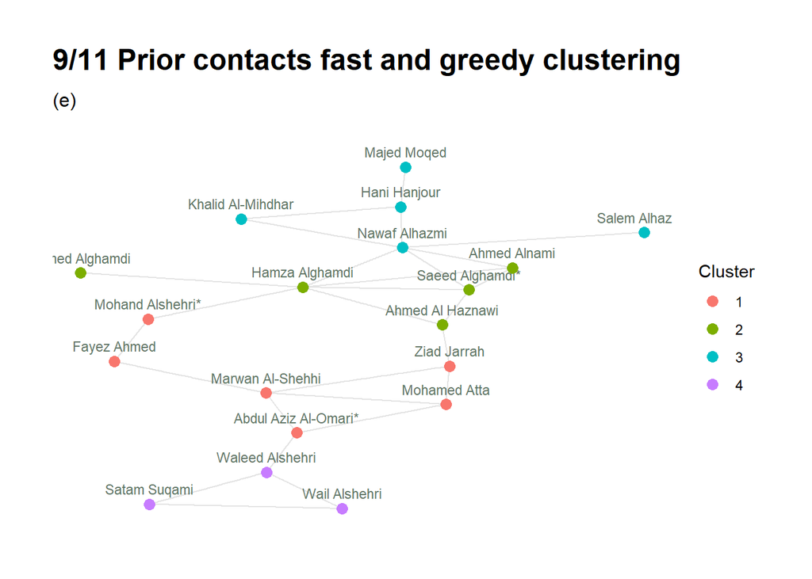

```r
set.seed(3)
g <- ggraph(priorContacts.911.igraph, layout = 'kk') +
  geom_edge_link(color = "gray89") +
  geom_node_text(
    aes(label = name),
    size = 3,
    colour = '#617566',
    nudge_y = 0.2, # adjust on y axis display of the terrorist name
    show.legend = FALSE
  ) +
  theme_graph()

Cluster = as.factor(PRIORCONTACTS_member.fg)

g +
  geom_node_point(aes(color = Cluster), size = 3, show.legend = TRUE) +
  ggtitle("9/11 Prior contacts fast and greedy clustering") +
  labs(subtitle = "(e)")
```

Now, lets see how the flight details maps on the clusters.

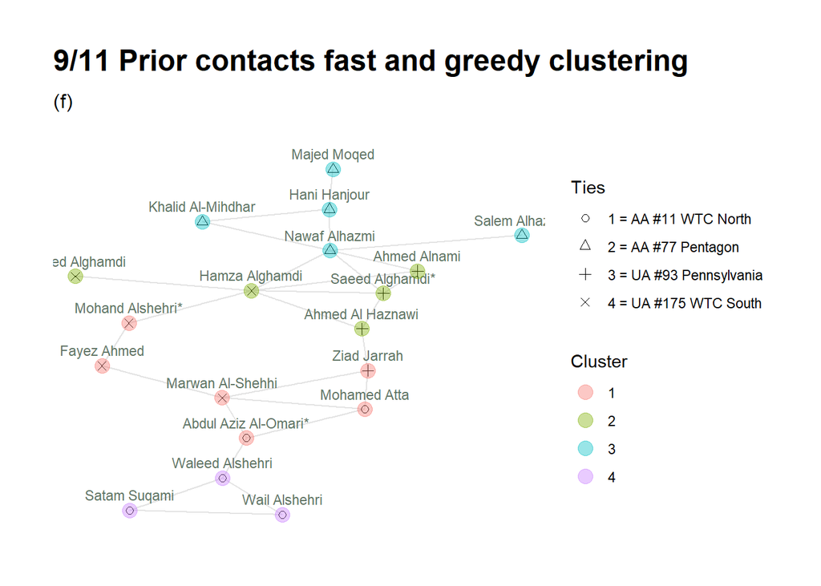

```r
g +
  geom_node_point(aes(shape = as.factor(PRIORCONTACTS$Ties) ),  size=2) +
  geom_node_point(aes(color = Cluster ), size = 4,  alpha=0.4) +
  scale_shape_manual(name= "Ties",
                     values= c(1, 2, 3, 4),
                     labels= c("1 = AA #11 WTC North",
                               "2 = AA #77 Pentagon",
                               "3 = UA #93 Pennsylvania",
                               "4 = UA #175 WTC South") ) +
  ggtitle("9/11 Prior contacts fast and greedy clustering") +
  labs(subtitle = "(f)")
```

From the above plot the algorithm catches one cluster (blue) which matches exactly the terrorist crew who crashed AA#77 on Pentagon. It looks like the reason why the fast and greedy was able to do so because Nawaf Alhazmi is the only broker node connecting his team to others.

Plotting the results of fast and greedy clustering for associates network.

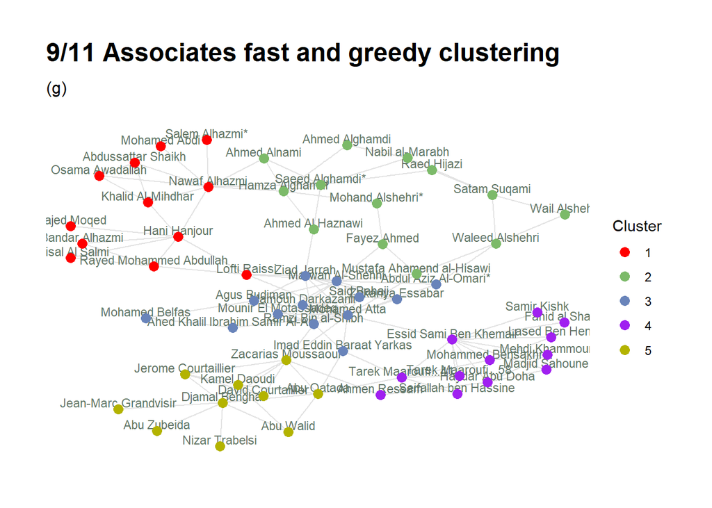

```r
set.seed(3)
ga <- ggraph(associates.911.igraph, layout = 'kk') +
  geom_edge_link(color = "gray89") +
  geom_node_text(
    aes(label = name),
    size = 3,
    colour = '#617566',
    nudge_y = 0.2, # adjust on y axis display of the terrorist name
    show.legend = FALSE
  ) +
  theme_graph()

ga +
  geom_node_point(aes(color = as.factor(ASSOCIATES_member.fg)), size = 3) +
  scale_color_manual(label= c(1,2,3,4,5), values = c("red", "#7cba69", "#6984ba", "purple", "#b3b300"), name= "Cluster") +
  ggtitle("9/11 Associates fast and greedy clustering") +
  labs(subtitle = "(g)")
```

Now, lets see how the flight details maps on the associates’ clusters.

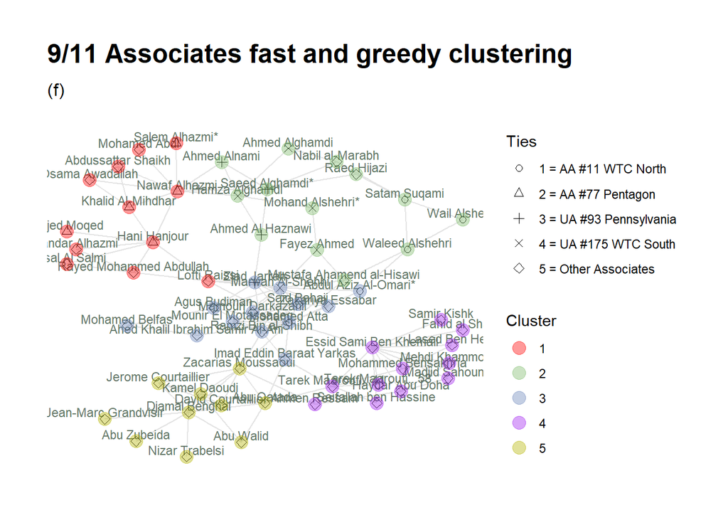

```r
ga +
  geom_node_point(aes(shape = as.factor(ASSOCIATES$Ties) ),  size=2) +
  geom_node_point(aes(color = as.factor(ASSOCIATES_member.fg) ), size = 4,  alpha=0.4) +
  scale_shape_manual(name= "Ties",
                     values= c(1, 2, 3, 4, 5),
                     labels= c("1 = AA #11 WTC North",
                               "2 = AA #77 Pentagon",
                               "3 = UA #93 Pennsylvania",
                               "4 = UA #175 WTC South",
                               "5 = Other Associates") ) +
  scale_color_manual(label= c(1,2,3,4,5), values = c("red", "#7cba69", "#6984ba", "purple", "#b3b300"), name= "Cluster") +

  ggtitle("9/11 Associates fast and greedy clustering") +
  labs(subtitle = "(f)")
```

### Community structure via short random walks

```r
PRIORCONTACTS.wt <-  cluster_walktrap(priorContacts.911.igraph)
PRIORCONTACTS.wt
```

```
## IGRAPH clustering walktrap, groups: 4, mod: 0.49
## + groups:
##   $`1`
##   [1] "Abdul Aziz Al-Omari*" "Mohamed Atta"         "Marwan Al-Shehhi"
##   [4] "Fayez Ahmed"          "Ziad Jarrah"          "Mohand Alshehri*"
##
##   $`2`
##   [1] "Salem Alhazmi*"   "Ahmed Alghamdi"   "Ahmed Alnami"
##   [4] "Nawaf Alhazmi"    "Saeed Alghamdi*"  "Ahmed Al Haznawi"
##   [7] "Hamza Alghamdi"
##
##   $`3`
##   + ... omitted several groups/vertices
```

```r
ASSOCIATES.wt <-  cluster_walktrap(associates.911.igraph)
ASSOCIATES.wt
```

```
## IGRAPH clustering walktrap, groups: 5, mod: 0.63
## + groups:
##   $`1`
##    [1] "Majed Moqed"             "Khalid Al-Mihdhar"
##    [3] "Hani Hanjour"            "Nawaf Alhazmi"
##    [5] "Salem Alhazmi*"          "Rayed Mohammed Abdullah"
##    [7] "Bandar Alhazmi"          "Faisal Al Salmi"
##    [9] "Osama Awadallah"         "Abdussattar Shaikh"
##   [11] "Mohamed Abdi"
##
##   $`2`
##    [1] "Ahmed Alnami"     "Ahmed Alghamdi"   "Saeed Alghamdi*"
##   + ... omitted several groups/vertices
```

```r
length(PRIORCONTACTS.wt)
```

```
## [1] 4
```

```r
length(ASSOCIATES.wt)
```

```
## [1] 5
```

There were 4 communities identified in the prior contacts network and 5 in the associates network which is the same case as with the fast and greedy algorithm.

What are their sizes?

```r
sizes(PRIORCONTACTS.wt)
```

```
## Community sizes
## 1 2 3 4
## 6 7 3 3
```

```r
sizes(ASSOCIATES.wt)
```

```
## Community sizes
##  1  2  3  4  5
## 11 10 17 12 10
```

Sizes of groups for prior contacts and associates look less balanced. The biggest group in prior contacts network with fast and greedy was 6 members, this time it is 7. In associates network it was 13 and now it is 17.

Who belongs to which community?

```r
PRIORCONTACTS_member.wt <-  membership(PRIORCONTACTS.wt)
PRIORCONTACTS_member.wt
```

```
##         Satam Suqami        Wail Alshehri          Majed Moqed
##                    4                    4                    3
##      Waleed Alshehri       Salem Alhazmi*    Khalid Al-Mihdhar
##                    4                    2                    3
##         Hani Hanjour Abdul Aziz Al-Omari*       Ahmed Alghamdi
##                    3                    1                    2
##         Ahmed Alnami         Mohamed Atta     Marwan Al-Shehhi
##                    2                    1                    1
##          Fayez Ahmed        Nawaf Alhazmi          Ziad Jarrah
##                    1                    2                    1
##     Mohand Alshehri*      Saeed Alghamdi*     Ahmed Al Haznawi
##                    1                    2                    2
##       Hamza Alghamdi
##                    2
```

```r
ASSOCIATES_member.wt <-  membership(ASSOCIATES.wt)
ASSOCIATES_member.wt
```

```
##                      Majed Moqed                Khalid Al-Mihdhar
##                                1                                1
##                     Hani Hanjour                    Nawaf Alhazmi
##                                1                                1
##                   Salem Alhazmi*                     Ahmed Alnami
##                                1                                2
##                   Ahmed Alghamdi                  Saeed Alghamdi*
##                                2                                2
##                   Hamza Alghamdi                 Ahmed Al Haznawi
##                                2                                2
##                 Mohand Alshehri*                      Fayez Ahmed
##                                3                                3
##                      Ziad Jarrah                 Marwan Al-Shehhi
##                                3                                3
##                     Mohamed Atta             Abdul Aziz Al-Omari*
##                                3                                3
##                  Waleed Alshehri                    Wail Alshehri
##                                2                                2
##                     Satam Suqami                      Raed Hijazi
##                                2                                2
##                  Nabil al-Marabh        Mustafa Ahamend al-Hisawi
##                                2                                3
##                Mamoun Darkazanli                 Zakariya Essabar
##                                3                                3
##                      Said Bahaji             Mounir El Motassadeq
##                                3                                3
##               Zacarias Moussaoui               Ramzi Bin al-Shibh
##                                5                                3
##                     Agus Budiman Ahed Khalil Ibrahim Samir Al-Ani
##                                3                                3
##                     Lofti Raissi          Rayed Mohammed Abdullah
##                                3                                1
##                   Bandar Alhazmi                  Faisal Al Salmi
##                                1                                1
##                  Osama Awadallah               Abdussattar Shaikh
##                                1                                1
##                     Mohamed Abdi                   Mohamed Belfas
##                                1                                3
##         Imad Eddin Baraat Yarkas              Tarek Maaroufi...41
##                                3                                4
##                       Abu Qatada                   Djamal Benghal
##                                5                                5
##              Jerome Courtaillier               David Courtaillier
##                                5                                5
##                     Ahmen Ressam                        Abu Walid
##                                4                                5
##             Jean-Marc Grandvisir                      Abu Zubeida
##                                5                                5
##                   Nizar Trabelsi                  Haydar Abu Doha
##                                5                                4
##                   Mehdi Khammoun              Mohammed Bensakhria
##                                4                                4
##                   Lased Ben Heni           Essid Sami Ben Khemail
##                                4                                4
##            Seifallah ben Hassine              Tarek Maaroufi...58
##                                4                                4
##                  Fahid al Shakri                   Madjid Sahoune
##                                4                                4
##                      Samir Kishk                     Kamel Daoudi
##                                4                                5
```

What is the modularity of the network?

```r
modularity(PRIORCONTACTS.wt)
```

```
## [1] 0.4890261
```

```r
modularity(ASSOCIATES.wt)
```

```
## [1] 0.634624
```

Modularity scores are slightly lower than in fast and greedy algorithm.

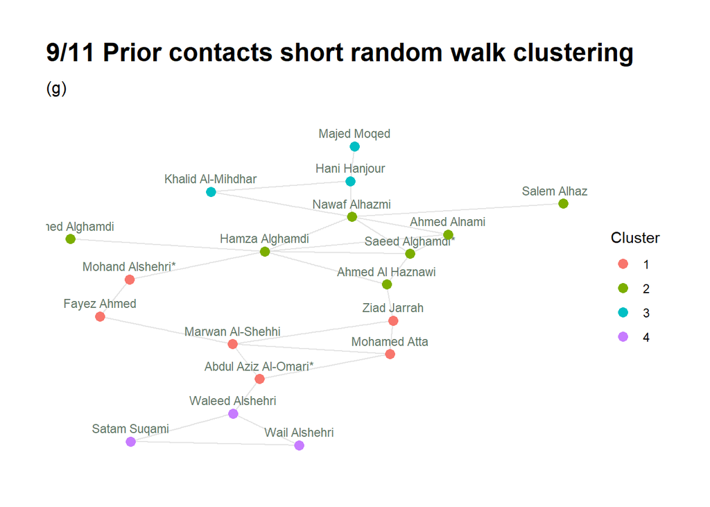

```r
set.seed(3)
gwt <- ggraph(priorContacts.911.igraph, layout = 'kk') +
  geom_edge_link(color = "gray89") +
  geom_node_text(
    aes(label = name),
    size = 3,
    colour = '#617566',
    nudge_y = 0.2, # adjust on y axis display of the terrorist name
    show.legend = FALSE
  ) +
  theme_graph()

Cluster = as.factor(PRIORCONTACTS_member.wt)

gwt +
  geom_node_point(aes(color = Cluster), size = 3, show.legend = TRUE) +
  ggtitle("9/11 Prior contacts short random walk clustering") +
  labs(subtitle = "(g)")
```

Now, lets see how the flight details maps on the clusters.

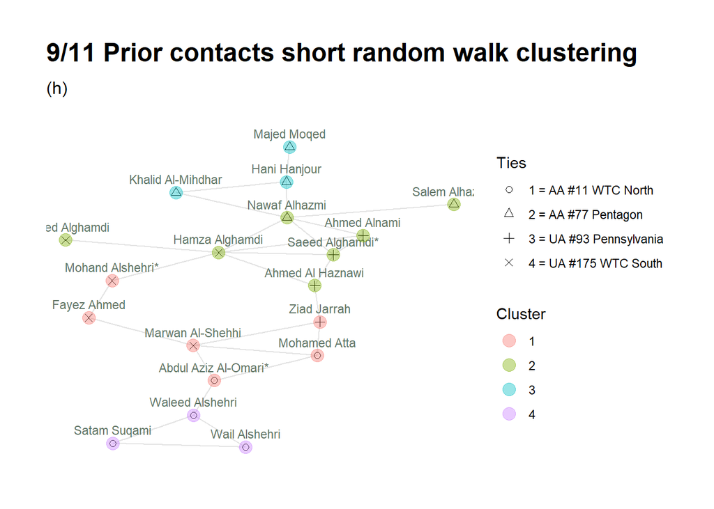

```r
gwt +
  geom_node_point(aes(shape = as.factor(PRIORCONTACTS$Ties) ),  size=2) +
  geom_node_point(aes(color = Cluster ), size = 4,  alpha=0.4) +
  scale_shape_manual(name= "Ties",
                     values= c(1, 2, 3, 4),
                     labels= c("1 = AA #11 WTC North",
                               "2 = AA #77 Pentagon",
                               "3 = UA #93 Pennsylvania",
                               "4 = UA #175 WTC South") ) +
  ggtitle("9/11 Prior contacts short random walk clustering") +
  labs(subtitle = "(h)")
```

In comparison with the previous algorithm it doesn’t capture any team who boarded a plane.

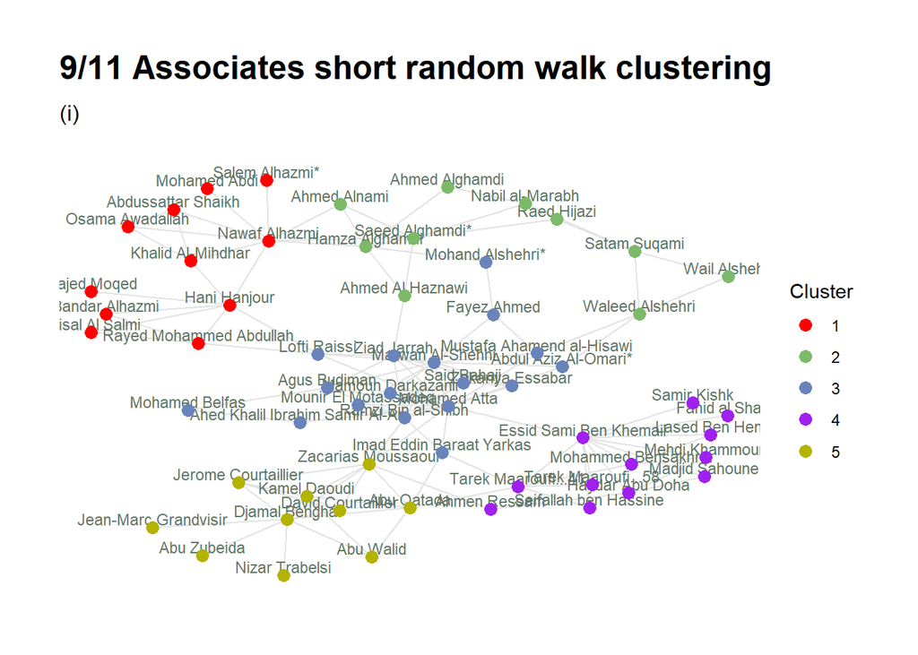

```r
set.seed(3)
gwta <- ggraph(associates.911.igraph, layout = 'kk') +
  geom_edge_link(color = "gray89") +
  geom_node_text(
    aes(label = name),
    size = 3,
    colour = '#617566',
    nudge_y = 0.2, # adjust on y axis display of the terrorist name
    show.legend = FALSE
  ) +
  theme_graph()

gwta +
  geom_node_point(aes(color = as.factor(ASSOCIATES_member.wt)), size = 3) +
  scale_color_manual(label= c(1,2,3,4,5), values = c("red", "#7cba69", "#6984ba", "purple", "#b3b300"), name= "Cluster") +
  ggtitle("9/11 Associates short random walk clustering") +
  labs(subtitle = "(i)")
```

Now, lets see how the flight details maps on the associates’ clusters.

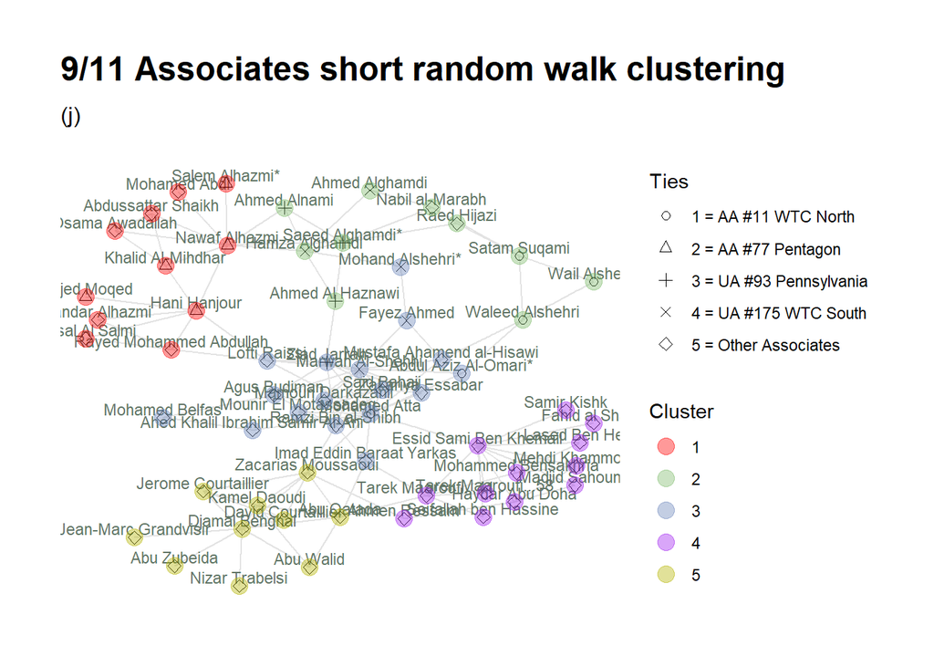

```r
gwta +
  geom_node_point(aes(shape = as.factor(ASSOCIATES$Ties) ),  size=2) +
  geom_node_point(aes(color = as.factor(ASSOCIATES_member.wt) ), size = 4,  alpha=0.4) +
  scale_shape_manual(name= "Ties",
                     values= c(1, 2, 3, 4, 5),
                     labels= c("1 = AA #11 WTC North",
                               "2 = AA #77 Pentagon",
                               "3 = UA #93 Pennsylvania",
                               "4 = UA #175 WTC South",
                               "5 = Other Associates") ) +
  scale_color_manual(label= c(1,2,3,4,5), values = c("red", "#7cba69", "#6984ba", "purple", "#b3b300"), name= "Cluster") +

  ggtitle("9/11 Associates short random walk clustering") +
  labs(subtitle = "(j)")
```

## 2. Uniform tests vs Erdos-Renyi model of the same (expected) density

## Answer

#### Test transitivity against size, density, and the dyad census

##### Prior contacts Test transitivity

```r
cug.test.gtrans.priorContacts.size <-  cug.test(dat=matrix_911_HIJACKERS_PRIORCONTACTS, gtrans, cmode="size", mode = "graph")
cug.test.gtrans.priorContacts.size
```

```
##
## Univariate Conditional Uniform Graph Test
##
## Conditioning Method: size
## Graph Type: graph
## Diagonal Used: FALSE
## Replications: 1000
##
## Observed Value: 0.3368421
## Pr(X>=Obs): 1
## Pr(X<=Obs): 0
```

```r
cug.test.gtrans.priorContacts.edges <- cug.test(dat=matrix_911_HIJACKERS_PRIORCONTACTS, gtrans, cmode="edges", mode = "graph")
cug.test.gtrans.priorContacts.edges
```

```
##
## Univariate Conditional Uniform Graph Test
##
## Conditioning Method: edges
## Graph Type: graph
## Diagonal Used: FALSE
## Replications: 1000
##
## Observed Value: 0.3368421
## Pr(X>=Obs): 0.005
## Pr(X<=Obs): 0.995
```

```r
cug.test.gtrans.priorContacts.dyad.census <- cug.test(dat=matrix_911_HIJACKERS_PRIORCONTACTS, gtrans, cmode="dyad.census", mode = "graph")
cug.test.gtrans.priorContacts.dyad.census
```

```
##
## Univariate Conditional Uniform Graph Test
##
## Conditioning Method: dyad.census
## Graph Type: graph
## Diagonal Used: FALSE
## Replications: 1000
##
## Observed Value: 0.3368421
## Pr(X>=Obs): 0.001
## Pr(X<=Obs): 0.999
```

##### Associates Test transitivity

```r
cug.test.gtrans.associates.size <-  cug.test(dat=matrix_911_HIJACKERS_ASSOCIATES, gtrans, cmode="size", mode = "graph")
cug.test.gtrans.associates.size
```

```
##
## Univariate Conditional Uniform Graph Test
##
## Conditioning Method: size
## Graph Type: graph
## Diagonal Used: FALSE
## Replications: 1000
##
## Observed Value: 0.3582555
## Pr(X>=Obs): 1
## Pr(X<=Obs): 0
```

```r
cug.test.gtrans.associates.edges <-cug.test(dat=matrix_911_HIJACKERS_ASSOCIATES, gtrans, cmode="edges", mode = "graph")
cug.test.gtrans.associates.edges
```

```
##
## Univariate Conditional Uniform Graph Test
##
## Conditioning Method: edges
## Graph Type: graph
## Diagonal Used: FALSE
## Replications: 1000
##
## Observed Value: 0.3582555
## Pr(X>=Obs): 0
## Pr(X<=Obs): 1
```

```r
cug.test.gtrans.associates.dyad.census <- cug.test(dat=matrix_911_HIJACKERS_ASSOCIATES, gtrans, cmode="dyad.census", mode = "graph")
cug.test.gtrans.associates.dyad.census
```

```
##
## Univariate Conditional Uniform Graph Test
##
## Conditioning Method: dyad.census
## Graph Type: graph
## Diagonal Used: FALSE
## Replications: 1000
##
## Observed Value: 0.3582555
## Pr(X>=Obs): 0
## Pr(X<=Obs): 1
```

#### Test Krackhardt connectedness scores against size, density, and the dyad census

##### Test Krackhardt connectedness for prior contacts

```r
#Test  Krackhardt connectedness scores against size, density, and the dyad census
cug.test.connectedness.priorContacts.size <-  cug.test(dat=matrix_911_HIJACKERS_PRIORCONTACTS, sna::connectedness, cmode="size", mode = "graph")
cug.test.connectedness.priorContacts.size
```

```
##
## Univariate Conditional Uniform Graph Test
##
## Conditioning Method: size
## Graph Type: graph
## Diagonal Used: FALSE
## Replications: 1000
##
## Observed Value: 1
## Pr(X>=Obs): 0.999
## Pr(X<=Obs): 1
```

```r
cug.test.connectedness.priorContacts.edges <- cug.test(dat=matrix_911_HIJACKERS_PRIORCONTACTS, sna::connectedness, cmode="edges", mode = "graph")
cug.test.connectedness.priorContacts.edges
```

```
##
## Univariate Conditional Uniform Graph Test
##
## Conditioning Method: edges
## Graph Type: graph
## Diagonal Used: FALSE
## Replications: 1000
##
## Observed Value: 1
## Pr(X>=Obs): 0.22
## Pr(X<=Obs): 1
```

```r
cug.test.connectedness.priorContacts.dyad.census <- cug.test(dat=matrix_911_HIJACKERS_PRIORCONTACTS, sna::connectedness, cmode="dyad.census", mode = "graph")
cug.test.connectedness.priorContacts.dyad.census
```

```
##
## Univariate Conditional Uniform Graph Test
##
## Conditioning Method: dyad.census
## Graph Type: graph
## Diagonal Used: FALSE
## Replications: 1000
##
## Observed Value: 1
## Pr(X>=Obs): 0.438
## Pr(X<=Obs): 1
```

##### Test Krackhardt connectedness for associates

```r
#Test  Krackhardt connectedness scores against size, density, and the dyad census
cug.test.connectedness.associates.size <-  cug.test(dat=matrix_911_HIJACKERS_ASSOCIATES, sna::connectedness, cmode="size", mode = "graph")
cug.test.connectedness.associates.size
```

```
##
## Univariate Conditional Uniform Graph Test
##
## Conditioning Method: size
## Graph Type: graph
## Diagonal Used: FALSE
## Replications: 1000
##
## Observed Value: 1
## Pr(X>=Obs): 1
## Pr(X<=Obs): 1
```

```r
cug.test.connectedness.associates.edges <- cug.test(dat=matrix_911_HIJACKERS_ASSOCIATES, sna::connectedness, cmode="edges", mode = "graph")
cug.test.connectedness.associates.edges
```

```
##
## Univariate Conditional Uniform Graph Test
##
## Conditioning Method: edges
## Graph Type: graph
## Diagonal Used: FALSE
## Replications: 1000
##
## Observed Value: 1
## Pr(X>=Obs): 0.062
## Pr(X<=Obs): 1
```

```r
cug.test.connectedness.associates.dyad.census <- cug.test(dat=matrix_911_HIJACKERS_ASSOCIATES, sna::connectedness, cmode="dyad.census", mode = "graph")
cug.test.connectedness.associates.dyad.census
```

```
##
## Univariate Conditional Uniform Graph Test
##
## Conditioning Method: dyad.census
## Graph Type: graph
## Diagonal Used: FALSE
## Replications: 1000
##
## Observed Value: 1
## Pr(X>=Obs): 0.46
## Pr(X<=Obs): 1
```

#### Test degree scores against size, density, and the dyad census

##### Test degree scores for prior contacts

```r
cug.test.degree.priorContacts.size <-  cug.test(dat=matrix_911_HIJACKERS_PRIORCONTACTS, FUN = sna::degree, cmode="size", mode = "graph")
cug.test.degree.priorContacts.size
```

```
##
## Univariate Conditional Uniform Graph Test
##
## Conditioning Method: size
## Graph Type: graph
## Diagonal Used: FALSE
## Replications: 1000
##
## Observed Value: 4 4 2 6 2 4 6 6 2 4 6 8 4 9 6 4 4 5 10
## Pr(X>=Obs): 0.995
## Pr(X<=Obs): 0.01
```

```r
cug.test.degree.priorContacts.edges <-  cug.test(dat=matrix_911_HIJACKERS_PRIORCONTACTS, FUN = sna::degree, cmode="edges", mode = "graph")
cug.test.degree.priorContacts.edges
```

```
##
## Univariate Conditional Uniform Graph Test
##
## Conditioning Method: edges
## Graph Type: graph
## Diagonal Used: FALSE
## Replications: 1000
##
## Observed Value: 4 4 2 6 2 4 6 6 2 4 6 8 4 9 6 4 4 5 10
## Pr(X>=Obs): 0.608
## Pr(X<=Obs): 0.592
```

```r
cug.test.degree.priorContacts.dyad.census <- cug.test(dat=matrix_911_HIJACKERS_PRIORCONTACTS, FUN = sna::degree, cmode="dyad.census", mode = "graph")
cug.test.degree.priorContacts.dyad.census
```

```
##
## Univariate Conditional Uniform Graph Test
##
## Conditioning Method: dyad.census
## Graph Type: graph
## Diagonal Used: FALSE
## Replications: 1000
##
## Observed Value: 4 4 2 6 2 4 6 6 2 4 6 8 4 9 6 4 4 5 10
## Pr(X>=Obs): 0.586
## Pr(X<=Obs): 0.539
```

##### Test degree scores for associates

```r
cug.test.degree.associates.size <-  cug.test(dat=matrix_911_HIJACKERS_ASSOCIATES, FUN = sna::degree, cmode="size", mode = "graph")
cug.test.degree.associates.size
```

```
##
## Univariate Conditional Uniform Graph Test
##
## Conditioning Method: size
## Graph Type: graph
## Diagonal Used: FALSE
## Replications: 1000
##
## Observed Value: 2 6 10 12 2 4 3 6 10 5 4 5 11 16 18 6 7 4 6 4 5 4 4 7 11 6 14 14 6 2 5 6 3 3 4 4 1 2 6 11 11 16 8 6 4 6 2 2 2 6 5 8 4 20 4 2 2 3 2 8
## Pr(X>=Obs): 1
## Pr(X<=Obs): 0
```

```r
cug.test.degree.associates.edges <-  cug.test(dat=matrix_911_HIJACKERS_ASSOCIATES, FUN = sna::degree, cmode="edges", mode = "graph")
cug.test.degree.associates.edges
```

```
##
## Univariate Conditional Uniform Graph Test
##
## Conditioning Method: edges
## Graph Type: graph
## Diagonal Used: FALSE
## Replications: 1000
##
## Observed Value: 2 6 10 12 2 4 3 6 10 5 4 5 11 16 18 6 7 4 6 4 5 4 4 7 11 6 14 14 6 2 5 6 3 3 4 4 1 2 6 11 11 16 8 6 4 6 2 2 2 6 5 8 4 20 4 2 2 3 2 8
## Pr(X>=Obs): 0.608
## Pr(X<=Obs): 0.489
```

```r
cug.test.degree.associates.dyad.census <- cug.test(dat=matrix_911_HIJACKERS_ASSOCIATES, FUN = sna::degree, cmode="dyad.census", mode = "graph")
cug.test.degree.associates.dyad.census
```

```
##
## Univariate Conditional Uniform Graph Test
##
## Conditioning Method: dyad.census
## Graph Type: graph
## Diagonal Used: FALSE
## Replications: 1000
##
## Observed Value: 2 6 10 12 2 4 3 6 10 5 4 5 11 16 18 6 7 4 6 4 5 4 4 7 11 6 14 14 6 2 5 6 3 3 4 4 1 2 6 11 11 16 8 6 4 6 2 2 2 6 5 8 4 20 4 2 2 3 2 8
## Pr(X>=Obs): 0.591
## Pr(X<=Obs): 0.475
```

#### Conditional Uniform Graph (CUG) Hypothesis Tests for Graph-Level Indices

Generate Erdos-Renyi random graph with the same number of nodes and expected density as the prior contacts network.

To generate the random graph it should have the fixed parameter of the density from the original dataset. Calculate the expected density for the prior contacts network.

```r
d_prior = gden(matrix_911_HIJACKERS_PRIORCONTACTS)
d_prior
```

```
## [1] 0.1403509
```

```r
set.seed(7)
er_prior = erdos.renyi.game(n = vcount(priorContacts.911.igraph), p = d_prior, type = "gnp")
er_adj_prior = get.adjacency(er_prior)
erMatr_prior = as.matrix(er_adj_prior)
```

```r
array_911_HIJACKERS_PRIORCONTACTS <-  as.array(matrix_911_HIJACKERS_PRIORCONTACTS)
# array_911_HIJACKERS_PRIORCONTACTS
```

```r
qap_prior <- array( dim = c(5,19,19) ) # creating an array with dimensions and values taken from matrices
qap_prior[1,,] <- df_911_HIJACKERS_ATTR_PRIORCONTACTS$Ties
qap_prior[2,,] <- df_911_HIJACKERS_ATTR_PRIORCONTACTS$`Las Vegas Meeting`
qap_prior[3,,] <- df_911_HIJACKERS_ATTR_PRIORCONTACTS$centralityPrior
qap_prior[4,,] <- array_911_HIJACKERS_PRIORCONTACTS # connections/ties between terrorists. matrix with ties converted to array
qap_prior[5,,] <- erMatr_prior                            # generated Erdos-Renyi random graph
```

$H_0$ - there is no difference in the connections distribution between our network and random network generated by Erdos-Renyi random graph $H_1$ - there is difference in the connections distribution between our network and random network generated by Erdos-Renyi random graph

```r
set.seed(8)
cugtest(dat = qap_prior, FUN = sna::gcor, g1=4, g2=5, cmode = "density", gmode = "graph")
```

```
##
## CUG Test Results
##
## Estimated p-values:
##  p(f(rnd) >= f(d)): 0.129
##  p(f(rnd) <= f(d)): 0.871
```

The p-value is greater than the significance level (normally accepted as 0.05), then we don’t have sufficient evidence to reject null hypothesis and conclude that the observed network has a different density distribution than the random graph.

Generate Erdos-Renyi random graph with the same number of nodes and expected density as the associates network.

```r
d_assoc = gden(matrix_911_HIJACKERS_ASSOCIATES)
d_assoc
```

```
## [1] 0.05367232
```

```r
set.seed(7)
er_assoc = erdos.renyi.game(n = vcount(associates.911.igraph), p = d_assoc, type = "gnp")
er_adj_assoc = get.adjacency(er_assoc)
erMatr_assoc = as.matrix(er_adj_assoc)
```

```r
array_911_HIJACKERS_ASSOCIATES <-  as.array(matrix_911_HIJACKERS_ASSOCIATES)
# array_911_HIJACKERS_ASSOCIATES
```

```r
qap_assoc <- array( dim = c(5,60,60) ) # creating an array with dimensions and values taken from matrices
qap_assoc[1,,] <- df_911_HIJACKERS_ATTR_ASSOCIATES$Ties
qap_assoc[2,,] <- df_911_HIJACKERS_ATTR_ASSOCIATES$`Las Vegas Meeting`
qap_assoc[3,,] <- df_911_HIJACKERS_ATTR_ASSOCIATES$centralityAssociates
qap_assoc[4,,] <- array_911_HIJACKERS_ASSOCIATES # connections/ties between terrorists. matrix with ties converted to array
qap_assoc[5,,] <- erMatr_assoc                            # generated Erdos-Renyi random graph
```

$H_0$ - there is no difference in the connections distribution between our network and random network generated by Erdos-Renyi random graph $H_1$ - there is difference in the connections distribution between our network and random network generated by Erdos-Renyi random graph

```r
set.seed(8)
cugtest(dat = qap_assoc, FUN = sna::gcor, g1=4, g2=5, cmode = "density", gmode = "graph")
```

```
##
## CUG Test Results
##
## Estimated p-values:
##  p(f(rnd) >= f(d)): 0.269
##  p(f(rnd) <= f(d)): 0.731
```

The p-value is greater than the significance level (normally accepted as 0.05), then we don’t have sufficient evidence to reject null hypothesis and conclude that the observed network has a different density distribution than the random graph.

#### Quadratic Assignment Procedure (QAP) Hypothesis Tests

The null hypothesis of the QAP test is that the observed graph-level statistic on graphs G_1,G_2,… was drawn from the distribution of said statistic evaluated (uniformly) on the set of all relabelings of G_1,G_2,…. Pragmatically, this test is performed by repeatedly (randomly) relabeling the input graphs, recalculating the test statistic, and then evaluating the fraction of draws greater than or equal to (and less than or equal to) the observed value. This accumulated fraction approximates the integral of the distribution of the test statistic over the set of unlabeled input graphs.

##### QAP for prior contacts

QAP of prior contacts Ties (flight #) and Las Vegas Meeting participation.

```r
qap_prior_test <- qaptest(dat=qap_prior, FUN = sna::gcor, g1=1,g2=2)
summary(qap_prior_test)
```

```
##
## QAP Test Results
##
## Estimated p-values:
##  p(f(perm) >= f(d)): 0.692
##  p(f(perm) <= f(d)): 0.46
##
## Test Diagnostics:
##  Test Value (f(d)): -0.08356487
##  Replications: 1000
##  Distribution Summary:
##      Min:     -0.6789646
##      1stQ:    -0.1827982
##      Med:     0.01566841
##      Mean:    -0.01241461
##      3rdQ:    0.1149017
##      Max:     0.7103014
```

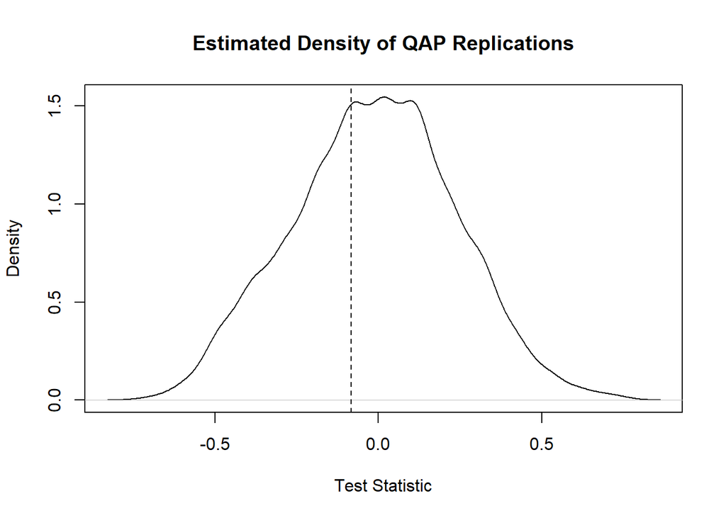

```r
plot(qap_prior_test)
```

QAP of prior contacts Ties (flight #) and computed centrality.

```r
qap_prior_test2 <- qaptest(dat=qap_prior, FUN = sna::gcor, g1=1,g2=3)
summary(qap_prior_test2)
```

```
##
## QAP Test Results
##
## Estimated p-values:
##  p(f(perm) >= f(d)): 0.668
##  p(f(perm) <= f(d)): 0.375
##
## Test Diagnostics:
##  Test Value (f(d)): -0.09691425
##  Replications: 1000
##  Distribution Summary:
##      Min:     -0.6756307
##      1stQ:    -0.1758301
##      Med:     -0.01799836
##      Mean:    0.001520169
##      3rdQ:    0.1661387
##      Max:     0.639634
```

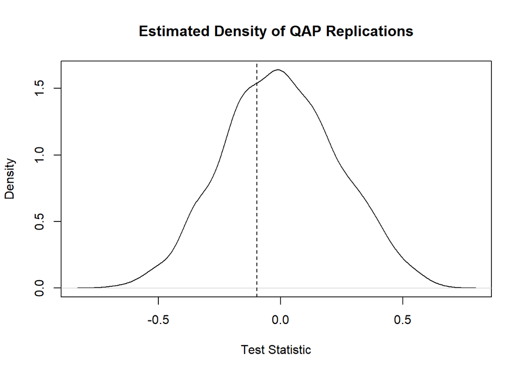

```r
plot(qap_prior_test2)
```

QAP of prior contacts Las Vegas Meeting and computed centrality.

```r
qap_prior_test3 <- qaptest(dat=qap_prior, FUN = sna::gcor, g1=2,g2=3)
summary(qap_prior_test3)
```

```
##
## QAP Test Results
##
## Estimated p-values:
##  p(f(perm) >= f(d)): 0.421
##  p(f(perm) <= f(d)): 0.688
##
## Test Diagnostics:
##  Test Value (f(d)): 0.07816621
##  Replications: 1000
##  Distribution Summary:
##      Min:     -0.6321267
##      1stQ:    -0.1801221
##      Med:     0.01359412
##      Mean:    -0.008037525
##      3rdQ:    0.1427383
##      Max:     0.7238871
```

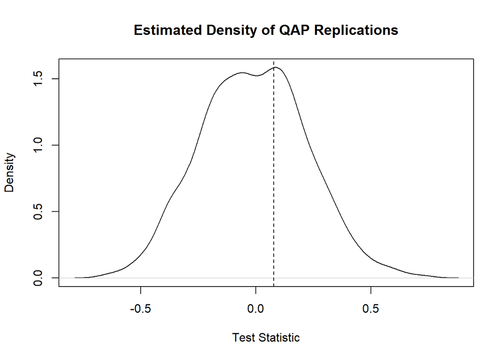

```r
plot(qap_prior_test3)
```

##### QAP for associates

```r
dim_len <- nrow(df_911_HIJACKERS_ATTR_ASSOCIATES)
qap_associates <- array( dim = c(3,dim_len,dim_len) )
qap_associates[1, , ] <- df_911_HIJACKERS_ATTR_ASSOCIATES$Ties
qap_associates[2, , ] <- df_911_HIJACKERS_ATTR_ASSOCIATES$`Las Vegas Meeting`
qap_associates[3, , ] <- df_911_HIJACKERS_ATTR_ASSOCIATES$centralityAssociates
# view(gq)
```

```r
qap_associates_test <- qaptest(dat=qap_associates, FUN = sna::gcor, g1=1, g2=2)
summary(qap_prior_test)
```

[output not shown]

[figure not shown]

```r
plot(qap_prior_test)
```

QAP of associates Ties (flight #) and computed centrality.

```r
qap_associates_test2 <- qaptest(dat=qap_associates, FUN = sna::gcor, g1=1,g2=3)
summary(qap_associates_test2)
```

```
##
## QAP Test Results
##
## Estimated p-values:
##  p(f(perm) >= f(d)): 0.854
##  p(f(perm) <= f(d)): 0.157
##
## Test Diagnostics:
##  Test Value (f(d)): -0.1329043
##  Replications: 1000
##  Distribution Summary:
##      Min:     -0.4391621
##      1stQ:    -0.08089828
##      Med:     0.0115569
##      Mean:    0.002008011
##      3rdQ:    0.08956595
##      Max:     0.3669315
```

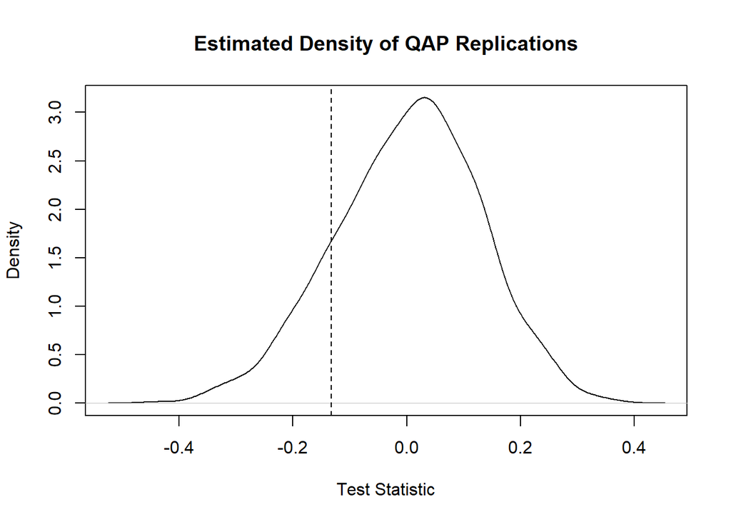

```r
plot(qap_associates_test2)
```

```r
qap_associates_test3 <- qaptest(dat=qap_associates, FUN = sna::gcor, g1=2,g2=3)
summary(qap_associates_test3)
```

```
##
## QAP Test Results
##
## Estimated p-values:
##  p(f(perm) >= f(d)): 0.004
##  p(f(perm) <= f(d)): 0.997
##
## Test Diagnostics:
##  Test Value (f(d)): 0.3998087
##  Replications: 1000
##  Distribution Summary:
##      Min:     -0.3095293
##      1stQ:    -0.1031764
##      Med:     -0.01289705
##      Mean:    0.00109625
##      3rdQ:    0.09027938
##      Max:     0.5158822
```

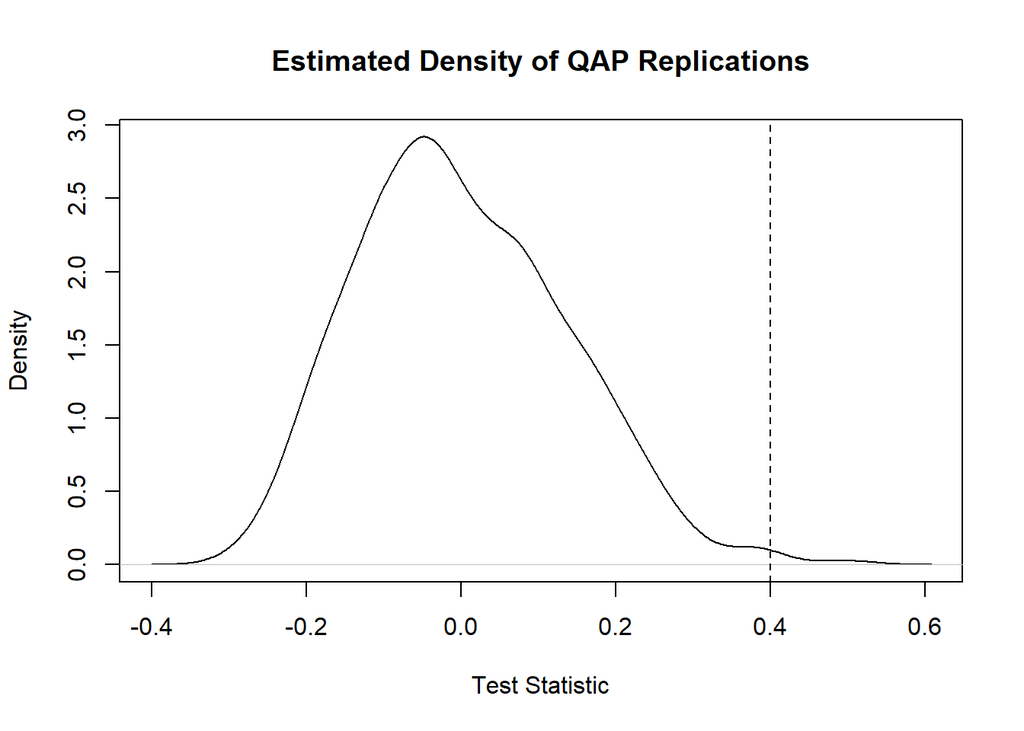

```r
plot(qap_associates_test3)
```

[^1]: Uncloaking Terrorist Networks by Veldis E. Krebs, access: https://firstmonday.org/ojs/index.php/fm/article/view/941/863